```python
%%shell
jupyter nbconvert --to html /content/drive/"My Drive"/Colab_Notebooks/yayfinal.ipynb
```

# **Migraine Comorbidity and Genetic Analysis: Data Science Final Tutorial**

## Maddie Bonanno and Riley Martin

our project website can be found at: https://mscb25.github.io/datasci-final-maddieriley/

# **Part 0: Initial Discussion**

### Purpose

Migraines are the 2nd most common cause of disability world wide. Presenting in a number of fashions, migraines are highly variable in triggers, symptoms, and severity. The purpose of this project is to explore the relationships between migraines and their comorbidities. Using medical history and genetic data, we aimed to explore how migraine occurance could possibly be linked to other factors.

We considered two common forms of migraine in this study - migraine with aura and migraine without aura:

- *Migraine without aura* = a neurological disease that often presents as a headache accompanied by nausea and sensitivity to external stimuli
- *Migraine with aur*a = the same critera as above ^ plus some form of visual, sensory, or motor disturbance that occurs before/during the attack

**Goals and Plans:**

Overall, through this assignment, we hoped to better understand the statistical association between migraines, common comorbidities, and genomics; this would allow for an improved understanding of the pathophysiology of migraines.

Some questions we wanted to explore are:

1. Are people with migraines more likely to have comorbidities?
2. If so, which types of comorbidities are most frequent in participants with migraines?
3. Is it possible that genetics plays a role in the likelihood of developing migraines?
4. Is there a particular subset of individuals migraines tend to impact?
5. Is there any difference in comorbidities between participants that have migraine with aura vs migraine without aura?

**Project Disclaimer:**

Through this research experiment, we wanted to explore statistical associations between migraines and the presentation of comorbidities + variance of genes. We are NOT claiming that migraines cause comorbidities or vise versa. We are also NOT claiming that allele varients between populations are a cause of migraines. Any usage of "correlation" or "causation" in this assignment refers to the percieved relationship between variables - it is not indicative of an accurate scientific conclusion.

**Collaboration Plan:**

To ensure completion of this project, we met at least twice a week. For most of the semester, we found Tuesday and Thursday evenings around 8pm to be optimal. Since we also had classes together each day, we utilized time before or after lecture to update one another on nightly progress. We also texted one another and shared planning documents via google drive. In addition, we often split tasks to optimize time, with Maddie organizing a majority of the data and Riley creating visual representations.

### Data Sources

For this project, we obtained data from the Personal Genome Project([PGP](https://https://www.personalgenomes.org/)). This open data source provided access to a number of statistics and participants used in this assignment.

**1) PGP Google Surveys**

Located at https://my.pgp-hms.org/google_surveys

Within the PGP data repositories, there are a number of 'participant surveys' filled out by the subject.

We utilized two of the general information surveys to gauge which populations were being represented.

- 1) [PGP Participant Survey](https://my.pgp-hms.org/google_surveys/1)

> *This google survey includes the 'Particpant' (represented by a 8 digit code) followed by personal information including : year of birth, sex/gender, and race/ethnicity*
- 2) [PGP Basic Phenotypes Survey 2015](https://my.pgp-hms.org/google_surveys/19)

> *This survey also includes the 'Participant' followed by various phenotypical categories including: height, blood type, and eye color*

We also collected data regarding the specific medical conditions participants had. Each file contained the 'Participant' and a column indicating whether they had a medical condition under that umbrella. The syndrome classes we looked at were:

- 1) [Nervous System](https://https://my.pgp-hms.org/google_surveys/9)

> *The occurance of migraines in participants was evaluated with this survey*
- 2) [Blood](https://https://my.pgp-hms.org/google_surveys/8)
- 3) [Vision and Hearing](https://https://my.pgp-hms.org/google_surveys/10)
- 4) [Circulatory System](https://https://my.pgp-hms.org/google_surveys/11)
- 5) [Digestive System](https://https://my.pgp-hms.org/google_surveys/13)
- 6) [Endocrine, Metabolic, Nutritional, and Immunity](https://my.pgp-hms.org/google_surveys/7)
- 7) [Respiratory System](https://https://my.pgp-hms.org/google_surveys/12)
- 8) [Skin and Subcutaneous Tissue](https://my.pgp-hms.org/google_surveys/15)
- 9) [Musculoskeletal System and Connective Tissue](https://https://my.pgp-hms.org/google_surveys/16)
- 10) [Genitourinary Systems](https://https://my.pgp-hms.org/google_surveys/14)
- 11) [Congenital Traits and Anomalies](https://my.pgp-hms.org/google_surveys/17)

These sources led to the culmination of data from 13 different google surveys.

**2) Get-Evidence Variant Reports - Genomic Data**

Given the medical histories of the patients (collected by the methods avove), we wanted to determine whether there was any genetic relation between migraines and/or comorbidities.

To achieve this goal, we scraped data from the PGP [Whole genome datasets](https://my.pgp-hms.org/users). Since only some participants had their genetic data uploaded, we filtered by 'Whole genome datasets' and accessed profiles with this component fufilled.

Since there was no dataset that contained all the information we desired, we took information from participant profiles and created a data source, which can be accessed [here](https://github.com/mscb25/datasci-final-maddieriley/blob/main/vari.xlsx).

*Methodology*:

1. Filtered participants based on whether 'Whole genome datasets' had a value > 0
2. Clicked on the first participant ID to access the "Participant Profile". Recorded the ID in the excel file.
3. Scrolled to the bottom of the page to find the links to this person's surveys. Clicked on the Nervous System conditions survey and checked if they had been diagnosed with any form of migraine; recorded 'mig with aura', 'mig no aura', 'both', or 'none' in the second column based on the survey response.
4. Next, clicked on 'View Report', a hyperlink located in the chart, to see the genetic data available for this participant. If the link was corrupt, the participant was discareded from the excel file.
5. On the new page named 'Variant report for (participant ID)", we recorded all the genes located in the "Show likely pathogenic and rare (<2.5%) pathogenic variants". The information in the "Impact" column was split into three excel columns: 'recessive or dominant', 'Homo/heterozyg', and 'Disease capacity'. Furthermore, the genes were labeled as "variant" unless specifically denoted as a mutation.
6. After this, genes under the "Insufficiently evaluated variants" tab were considered. Genes were recorded in the excel (following the previous criteria) if 1) the prioritization score was >5, or 2) the gene name includes "Shift" or "*" at the end - this denotes a mutation and should be recorded as such.
7. This process was repeated for each participant that had whole genome data publically available

**In summation, the rare variants and uncommon gene mutations were organized in a dataframe**

- genetic information was obtained from 137 unique participants

# **Part 1: Data Acquisition**

```python
import pandas as pd
import numpy as np
from google.colab import drive
drive.mount('/content/drive')
%cd /content/drive/My Drive/Colab_Notebooks
%matplotlib inline
import matplotlib as mpl
import matplotlib.pyplot as plt
from sklearn.feature_extraction import DictVectorizer
from sklearn.preprocessing import StandardScaler
from sklearn.neighbors import KNeighborsClassifier
from sklearn.pipeline import Pipeline
from sklearn.model_selection import cross_val_score
```

```
/content/drive/My Drive/Colab_Notebooks
```

### Google Survey Collection

As highlighted in Part 0, there are 13 different google surveys containing vital information about the medical history of the participants. Most of the challenges in this section arose from trying to present all the information in a digestible manner.

```python
# These are the 11 surveys containing medical conditions of each patient
# Each csv was read in

nerv_data = pd.read_csv("PGPTrait&DiseaseSurvey2012_NervousSystem-20181010220056 (1).csv")
circ_data = pd.read_csv('PGPTrait&DiseaseSurvey2012_CirculatorySystem-20181010220109.csv')
endo_data = pd.read_csv('PGPTrait&DiseaseSurvey2012_Endocrine,Metabolic,Nutritional,AndImmunity-20181010220044 (1).csv')
blood_data = pd.read_csv("PGPTrait&DiseaseSurvey2012_Blood-20181010220050.csv")
vis_hear_data = pd.read_csv("PGPTrait&DiseaseSurvey2012_VisionAndHearing-20181010220103.csv")
resp_data = pd.read_csv("PGPTrait&DiseaseSurvey2012_RespiratorySystem-20181010220114.csv")
digest_data = pd.read_csv("PGPTrait&DiseaseSurvey2012_DigestiveSystem-20181010214607.csv")
genit_data = pd.read_csv("PGPTrait&DiseaseSurvey2012_GenitourinarySystems-20181010214612.csv")
skin_data = pd.read_csv("PGPTrait&DiseaseSurvey2012_SkinAndSubcutaneousTissue-20181010214618.csv")
musculo_data = pd.read_csv("PGPTrait&DiseaseSurvey2012_MusculoskeletalSystemAndConnectiveTissue-20181010214624.csv")
congen_data = pd.read_csv("PGPTrait&DiseaseSurvey2012_CongenitalTraitsAndAnomalies-20181010214629.csv")

# Phenotypic and general physical traits (the other 2 surveys) were also read in

phenotypes = pd.read_csv("PGPBasicPhenotypesSurvey2015-20181010214636.csv")
gen_survey = pd.read_csv("PGPParticipantSurvey-20181010220019.csv")
```

```python
nerv_data.head() # All condition data takes on this format.
```

|  | Participant | Timestamp | Do not touch! | Have you ever been diagnosed with one of the following conditions? | Other condition not listed here? |
| --- | --- | --- | --- | --- | --- |
| 0 | hu3073E3 | 10/8/2012 21:22:10 | 4iq7dcisqa3zh75l1gmfxwvct1fs8n0k4g7gdzb2g559dt... | NaN | NaN |
| 1 | hu407142 | 10/9/2012 16:47:19 | 3dk0y4yds6u6pvp32azrysui4pbhhdn2y854l788d465w0... | NaN | NaN |
| 2 | huF974A8 | 10/9/2012 18:39:56 | 1pvw4ziy416x9ba0r31q6rhl917rle5g8bjgvzyfz678tr... | NaN | NaN |
| 3 | hu620F18 | 10/9/2012 19:18:30 | 2cmxvu2ozclqr135m573crz079idiw8m0boj3ie9fz257q... | Migraine without aura | NaN |
| 4 | hu3C0611 | 10/9/2012 19:29:14 | 43ogbna2kllvhfbjzljxzr6a0i6vf48mppgv0u8lys9lme... | Migraine without aura, Hereditary motor and se... | NaN |

```python
#putting all the csv's in a list format for easier manipulation
condition_data = [nerv_data,circ_data,endo_data,blood_data,vis_hear_data,resp_data,
                  digest_data,genit_data,skin_data,musculo_data,congen_data,]
```

```python
def drop_col(): # dropping unwanted columns
  for i in condition_data:
    i.drop("Do not touch!",axis=1,inplace=True)
    i.drop("Timestamp",axis=1,inplace=True)
    i.drop("Other condition not listed here?",axis=1,inplace=True)
drop_col()
```

```python
nerv_data.head() #now, this is how each dataframe looks
```

|  | Participant | Have you ever been diagnosed with one of the following conditions? |
| --- | --- | --- |
| 0 | hu3073E3 | NaN |
| 1 | hu407142 | NaN |
| 2 | huF974A8 | NaN |
| 3 | hu620F18 | Migraine without aura |
| 4 | hu3C0611 | Migraine without aura, Hereditary motor and se... |

```python
# renaming the columns for clarity
nerv_data.rename(columns={"Participant": "Participant","Have you ever been diagnosed with one of the following conditions?": 'Nervous System Conditions' },inplace=True)
circ_data.rename(columns={"Participant": "Participant","Have you ever been diagnosed with one of the following conditions?": 'Circulatory System Conditions'},inplace=True)
endo_data.rename(columns={"Participant": "Participant","Have you ever been diagnosed with any of the following conditions?": 'Endocrine System Conditions'},inplace=True)
blood_data.rename(columns={"Participant": "Participant","Have you ever been diagnosed with any of the following conditions?": 'Blood Conditions' },inplace=True)
vis_hear_data.rename(columns={"Participant": "Participant","Have you ever been diagnosed with one of the following conditions?": 'Visual and Hearing Conditions' },inplace=True)
resp_data.rename(columns={"Participant": "Participant","Have you ever been diagnosed with any of the following conditions?": 'Respiratory System Conditions'},inplace=True)
digest_data.rename(columns={"Participant": "Participant","Have you ever been diagnosed with any of the following conditions?": 'Digestive System Conditions'},inplace=True)
genit_data.rename(columns={"Participant": "Participant","Have you ever been diagnosed with any of the following conditions?": 'Genitourinary System Conditions'},inplace=True)
skin_data.rename(columns={"Participant": "Participant","Have you ever been diagnosed with any of the following conditions?": 'Skin Conditions'},inplace=True)
musculo_data.rename(columns={"Participant": "Participant","Have you ever been diagnosed with any of the following conditions?": 'Musculoskeletal System Conditions'},inplace=True)
congen_data.rename(columns={"Participant": "Participant","Have you ever been diagnosed with any of the following conditions?": 'Congenital Conditions'},inplace=True)
```

After each set of data was downloaded and cleaned, we were left with 11 frames of medical information. Since 'Participant' was a shared column in each, we used inner join to merge all the conditions into a singular dataframe.

```python
# merging into one df
conditions = condition_data[0].merge(condition_data[1],on="Participant",how="inner")
conditions = conditions.merge(condition_data[2],on="Participant",how="inner")
conditions = conditions.merge(condition_data[3],on="Participant",how="inner")
conditions = conditions.merge(condition_data[4],on="Participant",how="inner")
conditions = conditions.merge(condition_data[5],on="Participant",how="inner")
conditions = conditions.merge(condition_data[6],on="Participant",how="inner")
conditions = conditions.merge(condition_data[7],on="Participant",how="inner")
conditions = conditions.merge(condition_data[8],on="Participant",how="inner")
conditions = conditions.merge(condition_data[9],on="Participant",how="inner")
conditions = conditions.merge(condition_data[10],on="Participant",how="inner")
```

```python
conditions
```

|  | Participant | Nervous System Conditions | Circulatory System Conditions | Endocrine System Conditions | Blood Conditions | Visual and Hearing Conditions | Respiratory System Conditions | Digestive System Conditions | Genitourinary System Conditions | Skin Conditions | Musculoskeletal System Conditions | Congenital Conditions |
| --- | --- | --- | --- | --- | --- | --- | --- | --- | --- | --- | --- | --- |
| 0 | hu3073E3 | NaN | NaN | NaN | NaN | Age-related cataract, Myopia (Nearsightedness)... | Deviated septum, Allergic rhinitis | Dental cavities, Canker sores (oral ulcers), I... | Urinary tract infection (UTI) | Eczema, Allergic contact dermatitis, Hair loss... | Chondromalacia patella (CMP) | NaN |
| 1 | hu407142 | NaN | NaN | NaN | NaN | Myopia (Nearsightedness), Astigmatism, Dry eye... | Chronic sinusitis, Allergic rhinitis | Dental cavities | Urinary tract infection (UTI) | Acne | NaN | NaN |
| 2 | hu407142 | NaN | NaN | NaN | NaN | Myopia (Nearsightedness), Astigmatism, Dry eye... | Chronic sinusitis, Allergic rhinitis | Dental cavities | Urinary tract infection (UTI) | Acne | NaN | NaN |
| 3 | huF974A8 | NaN | NaN | NaN | NaN | Myopia (Nearsightedness), Dry eye syndrome, Fl... | NaN | Dental cavities, Canker sores (oral ulcers) | NaN | NaN | Osgood-Schlatter disease | NaN |
| 4 | hu620F18 | Migraine without aura | NaN | High cholesterol (hypercholesterolemia) | NaN | Myopia (Nearsightedness), Astigmatism, Floaters | NaN | Impacted tooth, Dental cavities, Gingivitis | NaN | Eczema, Allergic contact dermatitis, Skin tags | Sciatica | NaN |
| ... | ... | ... | ... | ... | ... | ... | ... | ... | ... | ... | ... | ... |
| 1151773 | huF8913E | Recurrent sleep paralysis, Restless legs syndr... | Hypertension, Hemorrhoids | Thyroid nodule(s), High cholesterol (hyperchol... | NaN | Myopia (Nearsightedness), Astigmatism, Floaters | Deviated septum, Chronic sinusitis, Allergic r... | Impacted tooth, Dental cavities, Canker sores ... | Urinary tract infection (UTI), Endometriosis | Dandruff, Acne | Sciatica, Tennis elbow, Bone spurs, Fibromyalg... | Spina bifida |
| 1151774 | hu794D40 | Recurrent sleep paralysis | Hypertension | Thyroid nodule(s) | NaN | Age-related macular degeneration | Nasal polyps, Chronic sinusitis, Chronic tonsi... | Dental cavities, Temporomandibular joint (TMJ)... | Urinary tract infection (UTI) | Eczema, Allergic contact dermatitis, Rosacea, ... | Postural kyphosis | NaN |
| 1151775 | huD8AD3F | Restless legs syndrome, Migraine with aura, Mi... | Angina, Cardiac arrhythmia | NaN | Iron deficiency anemia | Myopia (Nearsightedness), Tinnitus | NaN | Gastroesophageal reflux disease (GERD), Irrita... | Urinary tract infection (UTI), Ovarian cysts | Eczema, Allergic contact dermatitis, Hyperhidr... | Tennis elbow, Fibromyalgia, Scoliosis | NaN |
| 1151776 | hu35E970 | Essential tremor, Chronic tension headaches (1... | Raynaud's phenomenon | Thyroid nodule(s), Lactose intolerance | Iron deficiency anemia, Hereditary thrombophil... | NaN | Allergic rhinitis, Asthma | Dental cavities, Gingivitis, Canker sores (ora... | Urinary tract infection (UTI) | Dandruff, Allergic contact dermatitis, Rosacea | Frozen shoulder, Fibromyalgia | Developmental dysplasia of the hip |
| 1151777 | hu09787B | NaN | Hypertension, Hemorrhoids | Thyroid nodule(s), Hypothyroidism, Hashimoto's... | Von Willebrand disease | Myopia (Nearsightedness), Astigmatism, Age-rel... | Chronic sinusitis | Dental cavities, Gallstones | Kidney stones | Dandruff, Hair loss (includes female and male ... | Bone spurs, Osteoporosis, Scoliosis | Congenital clubfoot (equinovarus) |

1151778 rows × 12 columns

After merging, the resulting dataframe needed to be cleaned

```python
# Way too many rows
conditions['Participant'].value_counts()
# duplicates need to go
conditions = conditions.drop_duplicates(subset=['Participant'])
conditions
# duplicates gone but need to reset index
```

|  | Participant | Nervous System Conditions | Circulatory System Conditions | Endocrine System Conditions | Blood Conditions | Visual and Hearing Conditions | Respiratory System Conditions | Digestive System Conditions | Genitourinary System Conditions | Skin Conditions | Musculoskeletal System Conditions | Congenital Conditions |
| --- | --- | --- | --- | --- | --- | --- | --- | --- | --- | --- | --- | --- |
| 0 | hu3073E3 | NaN | NaN | NaN | NaN | Age-related cataract, Myopia (Nearsightedness)... | Deviated septum, Allergic rhinitis | Dental cavities, Canker sores (oral ulcers), I... | Urinary tract infection (UTI) | Eczema, Allergic contact dermatitis, Hair loss... | Chondromalacia patella (CMP) | NaN |
| 1 | hu407142 | NaN | NaN | NaN | NaN | Myopia (Nearsightedness), Astigmatism, Dry eye... | Chronic sinusitis, Allergic rhinitis | Dental cavities | Urinary tract infection (UTI) | Acne | NaN | NaN |
| 3 | huF974A8 | NaN | NaN | NaN | NaN | Myopia (Nearsightedness), Dry eye syndrome, Fl... | NaN | Dental cavities, Canker sores (oral ulcers) | NaN | NaN | Osgood-Schlatter disease | NaN |
| 4 | hu620F18 | Migraine without aura | NaN | High cholesterol (hypercholesterolemia) | NaN | Myopia (Nearsightedness), Astigmatism, Floaters | NaN | Impacted tooth, Dental cavities, Gingivitis | NaN | Eczema, Allergic contact dermatitis, Skin tags | Sciatica | NaN |
| 5 | hu3C0611 | Migraine without aura, Hereditary motor and se... | NaN | Thyroid nodule(s), Hypothyroidism, Hashimoto's... | Iron deficiency anemia | Floaters | Chronic tonsillitis, Allergic rhinitis, Asthma | Dental cavities | Kidney stones, Urinary tract infection (UTI) | Eczema, Keloids | Bunions, Plantar fasciitis | NaN |
| ... | ... | ... | ... | ... | ... | ... | ... | ... | ... | ... | ... | ... |
| 1151773 | huF8913E | Recurrent sleep paralysis, Restless legs syndr... | Hypertension, Hemorrhoids | Thyroid nodule(s), High cholesterol (hyperchol... | NaN | Myopia (Nearsightedness), Astigmatism, Floaters | Deviated septum, Chronic sinusitis, Allergic r... | Impacted tooth, Dental cavities, Canker sores ... | Urinary tract infection (UTI), Endometriosis | Dandruff, Acne | Sciatica, Tennis elbow, Bone spurs, Fibromyalg... | Spina bifida |
| 1151774 | hu794D40 | Recurrent sleep paralysis | Hypertension | Thyroid nodule(s) | NaN | Age-related macular degeneration | Nasal polyps, Chronic sinusitis, Chronic tonsi... | Dental cavities, Temporomandibular joint (TMJ)... | Urinary tract infection (UTI) | Eczema, Allergic contact dermatitis, Rosacea, ... | Postural kyphosis | NaN |
| 1151775 | huD8AD3F | Restless legs syndrome, Migraine with aura, Mi... | Angina, Cardiac arrhythmia | NaN | Iron deficiency anemia | Myopia (Nearsightedness), Tinnitus | NaN | Gastroesophageal reflux disease (GERD), Irrita... | Urinary tract infection (UTI), Ovarian cysts | Eczema, Allergic contact dermatitis, Hyperhidr... | Tennis elbow, Fibromyalgia, Scoliosis | NaN |
| 1151776 | hu35E970 | Essential tremor, Chronic tension headaches (1... | Raynaud's phenomenon | Thyroid nodule(s), Lactose intolerance | Iron deficiency anemia, Hereditary thrombophil... | NaN | Allergic rhinitis, Asthma | Dental cavities, Gingivitis, Canker sores (ora... | Urinary tract infection (UTI) | Dandruff, Allergic contact dermatitis, Rosacea | Frozen shoulder, Fibromyalgia | Developmental dysplasia of the hip |
| 1151777 | hu09787B | NaN | Hypertension, Hemorrhoids | Thyroid nodule(s), Hypothyroidism, Hashimoto's... | Von Willebrand disease | Myopia (Nearsightedness), Astigmatism, Age-rel... | Chronic sinusitis | Dental cavities, Gallstones | Kidney stones | Dandruff, Hair loss (includes female and male ... | Bone spurs, Osteoporosis, Scoliosis | Congenital clubfoot (equinovarus) |

1767 rows × 12 columns

```python
conditions = conditions.reset_index(drop=True)
conditions
```

|  | Participant | Nervous System Conditions | Circulatory System Conditions | Endocrine System Conditions | Blood Conditions | Visual and Hearing Conditions | Respiratory System Conditions | Digestive System Conditions | Genitourinary System Conditions | Skin Conditions | Musculoskeletal System Conditions | Congenital Conditions |
| --- | --- | --- | --- | --- | --- | --- | --- | --- | --- | --- | --- | --- |
| 0 | hu3073E3 | NaN | NaN | NaN | NaN | Age-related cataract, Myopia (Nearsightedness)... | Deviated septum, Allergic rhinitis | Dental cavities, Canker sores (oral ulcers), I... | Urinary tract infection (UTI) | Eczema, Allergic contact dermatitis, Hair loss... | Chondromalacia patella (CMP) | NaN |
| 1 | hu407142 | NaN | NaN | NaN | NaN | Myopia (Nearsightedness), Astigmatism, Dry eye... | Chronic sinusitis, Allergic rhinitis | Dental cavities | Urinary tract infection (UTI) | Acne | NaN | NaN |
| 2 | huF974A8 | NaN | NaN | NaN | NaN | Myopia (Nearsightedness), Dry eye syndrome, Fl... | NaN | Dental cavities, Canker sores (oral ulcers) | NaN | NaN | Osgood-Schlatter disease | NaN |
| 3 | hu620F18 | Migraine without aura | NaN | High cholesterol (hypercholesterolemia) | NaN | Myopia (Nearsightedness), Astigmatism, Floaters | NaN | Impacted tooth, Dental cavities, Gingivitis | NaN | Eczema, Allergic contact dermatitis, Skin tags | Sciatica | NaN |
| 4 | hu3C0611 | Migraine without aura, Hereditary motor and se... | NaN | Thyroid nodule(s), Hypothyroidism, Hashimoto's... | Iron deficiency anemia | Floaters | Chronic tonsillitis, Allergic rhinitis, Asthma | Dental cavities | Kidney stones, Urinary tract infection (UTI) | Eczema, Keloids | Bunions, Plantar fasciitis | NaN |
| ... | ... | ... | ... | ... | ... | ... | ... | ... | ... | ... | ... | ... |
| 1762 | huF8913E | Recurrent sleep paralysis, Restless legs syndr... | Hypertension, Hemorrhoids | Thyroid nodule(s), High cholesterol (hyperchol... | NaN | Myopia (Nearsightedness), Astigmatism, Floaters | Deviated septum, Chronic sinusitis, Allergic r... | Impacted tooth, Dental cavities, Canker sores ... | Urinary tract infection (UTI), Endometriosis | Dandruff, Acne | Sciatica, Tennis elbow, Bone spurs, Fibromyalg... | Spina bifida |
| 1763 | hu794D40 | Recurrent sleep paralysis | Hypertension | Thyroid nodule(s) | NaN | Age-related macular degeneration | Nasal polyps, Chronic sinusitis, Chronic tonsi... | Dental cavities, Temporomandibular joint (TMJ)... | Urinary tract infection (UTI) | Eczema, Allergic contact dermatitis, Rosacea, ... | Postural kyphosis | NaN |
| 1764 | huD8AD3F | Restless legs syndrome, Migraine with aura, Mi... | Angina, Cardiac arrhythmia | NaN | Iron deficiency anemia | Myopia (Nearsightedness), Tinnitus | NaN | Gastroesophageal reflux disease (GERD), Irrita... | Urinary tract infection (UTI), Ovarian cysts | Eczema, Allergic contact dermatitis, Hyperhidr... | Tennis elbow, Fibromyalgia, Scoliosis | NaN |
| 1765 | hu35E970 | Essential tremor, Chronic tension headaches (1... | Raynaud's phenomenon | Thyroid nodule(s), Lactose intolerance | Iron deficiency anemia, Hereditary thrombophil... | NaN | Allergic rhinitis, Asthma | Dental cavities, Gingivitis, Canker sores (ora... | Urinary tract infection (UTI) | Dandruff, Allergic contact dermatitis, Rosacea | Frozen shoulder, Fibromyalgia | Developmental dysplasia of the hip |
| 1766 | hu09787B | NaN | Hypertension, Hemorrhoids | Thyroid nodule(s), Hypothyroidism, Hashimoto's... | Von Willebrand disease | Myopia (Nearsightedness), Astigmatism, Age-rel... | Chronic sinusitis | Dental cavities, Gallstones | Kidney stones | Dandruff, Hair loss (includes female and male ... | Bone spurs, Osteoporosis, Scoliosis | Congenital clubfoot (equinovarus) |

1767 rows × 12 columns

Now, it is evident that there are 1767 unique participants that shared their full medical history.

The next step was to determine how many of these individuals had been diagnosed with migraines.

```python
# number of people with migraines
mig_w_aura = conditions['Nervous System Conditions'].str.contains('Migraine with aura', case=False, na=False)
w_sum = mig_w_aura.sum()
mig_no_aura = conditions['Nervous System Conditions'].str.contains('Migraine without aura', case=False, na=False)
no_sum = mig_no_aura.sum()
w_sum, no_sum
```

```
(215, 218)
```

```python
# just Participants with migraines
only_mig_haver = conditions[mig_w_aura | mig_no_aura]
only_mig_haver.Participant.count()
```

```
384
```

```python
only_mig_haver
```

|  | Participant | Nervous System Conditions | Circulatory System Conditions | Endocrine System Conditions | Blood Conditions | Visual and Hearing Conditions | Respiratory System Conditions | Digestive System Conditions | Genitourinary System Conditions | Skin Conditions | Musculoskeletal System Conditions | Congenital Conditions |
| --- | --- | --- | --- | --- | --- | --- | --- | --- | --- | --- | --- | --- |
| 3 | hu620F18 | Migraine without aura | NaN | High cholesterol (hypercholesterolemia) | NaN | Myopia (Nearsightedness), Astigmatism, Floaters | NaN | Impacted tooth, Dental cavities, Gingivitis | NaN | Eczema, Allergic contact dermatitis, Skin tags | Sciatica | NaN |
| 4 | hu3C0611 | Migraine without aura, Hereditary motor and se... | NaN | Thyroid nodule(s), Hypothyroidism, Hashimoto's... | Iron deficiency anemia | Floaters | Chronic tonsillitis, Allergic rhinitis, Asthma | Dental cavities | Kidney stones, Urinary tract infection (UTI) | Eczema, Keloids | Bunions, Plantar fasciitis | NaN |
| 5 | hu384E20 | Migraine with aura | Hemorrhoids | NaN | NaN | Floaters | NaN | Dental cavities, Temporomandibular joint (TMJ)... | NaN | Dandruff, Eczema | Scoliosis | NaN |
| 12 | hu5FCE15 | Migraine with aura | NaN | NaN | NaN | Myopia (Nearsightedness), Astigmatism | NaN | Dental cavities, Geographic tongue, Irritable ... | NaN | Acne | NaN | NaN |
| 17 | hu1EE386 | Migraine without aura | Hypertension, Raynaud's phenomenon | NaN | NaN | Myopia (Nearsightedness), Astigmatism | NaN | Dental cavities | Urinary tract infection (UTI), Endometriosis, ... | NaN | Fibromyalgia | NaN |
| ... | ... | ... | ... | ... | ... | ... | ... | ... | ... | ... | ... | ... |
| 1752 | huCD1A7A | Chronic tension headaches (15+ days per month,... | NaN | NaN | NaN | Myopia (Nearsightedness), Astigmatism, Presbyo... | NaN | Dental cavities, Temporomandibular joint (TMJ)... | Urinary tract infection (UTI), Ovarian cysts | NaN | Osteoarthritis, Frozen shoulder, Tennis elbow,... | NaN |
| 1753 | huA9AFFD | Chronic tension headaches (15+ days per month,... | NaN | Hypothyroidism, Lactose intolerance, High chol... | Iron deficiency anemia | Myopia (Nearsightedness), Astigmatism | Deviated septum, Chronic sinusitis, Chronic to... | Impacted tooth, Dental cavities, Gingivitis, T... | Kidney stones | Dandruff, Skin tags, Hair loss (includes femal... | Frozen shoulder, Tennis elbow, Plantar fasciit... | Ehlers-Danlos syndrome |
| 1759 | huC8E030 | Chronic tension headaches (15+ days per month,... | Hypertension, Cardiac arrhythmia, Varicose veins | Thyroid nodule(s), Hypothyroidism, Hashimoto's... | Iron deficiency anemia | Hyperopia (Farsightedness), Presbyopia, Dry ey... | Deviated septum, Nasal polyps, Chronic sinusit... | Impacted tooth, Dental cavities, Gingivitis, T... | Urinary tract infection (UTI), Endometriosis, ... | Dandruff, Eczema, Allergic contact dermatitis,... | Osteoarthritis, Chondromalacia patella (CMP), ... | NaN |
| 1762 | huF8913E | Recurrent sleep paralysis, Restless legs syndr... | Hypertension, Hemorrhoids | Thyroid nodule(s), High cholesterol (hyperchol... | NaN | Myopia (Nearsightedness), Astigmatism, Floaters | Deviated septum, Chronic sinusitis, Allergic r... | Impacted tooth, Dental cavities, Canker sores ... | Urinary tract infection (UTI), Endometriosis | Dandruff, Acne | Sciatica, Tennis elbow, Bone spurs, Fibromyalg... | Spina bifida |
| 1764 | huD8AD3F | Restless legs syndrome, Migraine with aura, Mi... | Angina, Cardiac arrhythmia | NaN | Iron deficiency anemia | Myopia (Nearsightedness), Tinnitus | NaN | Gastroesophageal reflux disease (GERD), Irrita... | Urinary tract infection (UTI), Ovarian cysts | Eczema, Allergic contact dermatitis, Hyperhidr... | Tennis elbow, Fibromyalgia, Scoliosis | NaN |

384 rows × 12 columns

Out of the dataset, there are 384 individuals with migraines. 215 participants have migraine with aura, while 218 have migraine without aura

Then, we needed to process and clean the phenotypic data for the participants

```python
# Now need to clean up phenotype and general data
phenotypes.columns
```

```
Index(['Participant', 'Timestamp', 'Do not touch!', '1.1 — Blood Type',
       '1.2 — Height', '1.3 — Weight', '1.4 — Comments',
       '2.1 — Left Eye (Photograph Number)  (full-size image: https://goo.gl/XQ2Voh)',
       '2.2 — Right Eye (Photograph Number)  (full-size image: https://goo.gl/XQ2Voh)',
       '2.3 — Left Eye Color - Text Description',
       '2.4 — Right Eye Color - Text Description', '2.5 —Comments',
       '3.1 — What is your natural hair color currently, when without artificial color or dye?',
       '3.2 — Hair Color - Text Description', '3.3 — Comments',
       '4.1 — Any final thoughts?', '1.4 — Handedness'],
      dtype='object')
```

```python
# columns to drop
unwanted_traits =['1.4 — Comments',
       '2.1 — Left Eye (Photograph Number)  (full-size image: https://goo.gl/XQ2Voh)',
       '2.2 — Right Eye (Photograph Number)  (full-size image: https://goo.gl/XQ2Voh)',
       '2.3 — Left Eye Color - Text Description',
       '2.4 — Right Eye Color - Text Description', '2.5 —Comments',
       '3.1 — What is your natural hair color currently, when without artificial color or dye?',
       '3.2 — Hair Color - Text Description', '3.3 — Comments',
       '4.1 — Any final thoughts?', '1.4 — Handedness','Timestamp', 'Do not touch!']

phenotypes = phenotypes.drop(unwanted_traits,axis=1)
```

```python
# desired columns
phenotypes.rename(columns={'1.1 — Blood Type': 'Blood Type',	'1.2 — Height': 'Height (in)',	'1.3 — Weight': 'Weight (lbs)'},inplace=True)
```

```python
# lots of null values present
phenotypes.isnull().sum()
```

```
Participant      0
Blood Type      42
Height (in)     23
Weight (lbs)    26
dtype: int64
```

```python
# ensuring all the NaN values are dropped
phenotypes = phenotypes.dropna()
phenotypes = phenotypes.reset_index(drop=True)
phenotypes
```

|  | Participant | Blood Type | Height (in) | Weight (lbs) |
| --- | --- | --- | --- | --- |
| 0 | hu826751 | AB + | 6'2" | 188.0 |
| 1 | huDDCF88 | O + | 5'10" | 159.0 |
| 2 | hu3DC5EA | A + | 5'5" | 184.0 |
| 3 | hu008567 | O + | 5'1" | 138.0 |
| 4 | hu98FFC6 | A + | 5'5" | 230.0 |
| ... | ... | ... | ... | ... |
| 1096 | huF8913E | O + | 5'6" | 185.0 |
| 1097 | hu794D40 | A + | 5'9" | 170.0 |
| 1098 | huD8AD3F | O + | 5'5" | 108.0 |
| 1099 | hu09787B | O + | 5'9" | 233.0 |
| 1100 | huF5CD05 | A + | 5'5" | 215.0 |

1101 rows × 4 columns

When that was completed, we moved onto cleaning the general traits frame

```python
# cleaning up the traits data
gen_survey.columns
```

```
Index(['Participant', 'Timestamp', 'Do not touch!', 'Year of birth',
       'Which statement best describes you?',
       'Severe disease or rare genetic trait',
       'Do you have a severe genetic disease or rare genetic trait? If so, you can add a description for your public profile.',
       'Disease/trait: Onset', 'Disease/trait: Rarity',
       'Disease/trait: Severity', 'Disease/trait: Relative enrollment',
       'Disease/trait: Diagnosis', 'Disease/trait: Genetic confirmation',
       'Disease/trait: Documentation',
       'Disease/trait: Documentation description', 'Sex/Gender',
       'Race/ethnicity', 'Maternal grandmother: Country of origin',
       'Paternal grandmother: Country of origin',
       'Paternal grandfather: Country of origin',
       'Maternal grandfather: Country of origin', 'Enrollment of relatives',
       'Enrollment of older individuals', 'Enrollment of parents',
       'Enrolled relatives [Monozygotic / Identical twins]',
       'Enrolled relatives [Parents]',
       'Enrolled relatives [Siblings / Fraternal twins]',
       'Enrolled relatives [Children]', 'Enrolled relatives [Grandparents]',
       'Enrolled relatives [Grandchildren]',
       'Enrolled relatives [Aunts/Uncles]',
       'Enrolled relatives [Nephews/Nieces]',
       'Enrolled relatives [Half-siblings]',
       'Enrolled relatives [Cousins or more distant]',
       'Enrolled relatives [Not genetically related (e.g. husband/wife)]',
       'Are all your enrolled relatives linked to your PGP profile?',
       'Have you uploaded genetic data to your PGP participant profile?',
       'Have you used the PGP web interface to record a designated proxy?',
       'Have you uploaded health record data using our Google Health or Microsoft Healthvault interfaces?',
       'Uploaded health records: Update status',
       'Uploaded health records: Extensiveness', 'Blood sample',
       'Saliva sample', 'Microbiome samples', 'Tissue samples from surgery',
       'Tissue samples from autopsy', 'Month of birth',
       'Anatomical sex at birth', 'Maternal grandmother: Race/ethnicity',
       'Maternal grandfather: Race/ethnicity',
       'Paternal grandmother: Race/ethnicity',
       'Paternal grandfather: Race/ethnicity'],
      dtype='object')
```

```python
# grabbing the traits we're interested in
traits = gen_survey[['Participant','Sex/Gender','Race/ethnicity']]
```

```python
# using more descriptive categories for race/ethnicity
traits['Race/ethnicity'] = traits['Race/ethnicity'].str.split(n=3).str[:3].str.join(' ')
```

```python
traits['Race/ethnicity'].value_counts()
```

```
White                     3532
American Indian /          155
Asian                      126
Hispanic or Latino,         82
Black or African            64
Hispanic or Latino          61
Asian, White                40
No response                 30
Asian, Native Hawaiian       7
White, No response           5
Native Hawaiian or           3
Asian, Hispanic or           2
Asian, Black or              1
Name: Race/ethnicity, dtype: int64
```

```python
# replacing the column titles with grammatically correct names
traits['Race/ethnicity'] = traits['Race/ethnicity'].replace({'American Indian /':'American Indian','Hispanic or Latino,': 'Hispanic or Latino',
                                                             'Asian, White': 'Asian', 'or': '','Asian, Black or': 'Asian', 'White, No response': 'White',
                                                             'Native Hawaiian or': 'Native Hawaiian'})
```

After that, we merged all the conditions, phenotypes, and general data into one singular df

```python
# merging all
all = conditions.merge(phenotypes,how='inner',on=['Participant'])
all = all.merge(traits,how='inner',on=['Participant'])
```

```python
all
```

|  | Participant | Nervous System Conditions | Circulatory System Conditions | Endocrine System Conditions | Blood Conditions | Visual and Hearing Conditions | Respiratory System Conditions | Digestive System Conditions | Genitourinary System Conditions | Skin Conditions | Musculoskeletal System Conditions | Congenital Conditions | Blood Type | Height (in) | Weight (lbs) | Sex/Gender | Race/ethnicity |
| --- | --- | --- | --- | --- | --- | --- | --- | --- | --- | --- | --- | --- | --- | --- | --- | --- | --- |
| 0 | hu620F18 | Migraine without aura | NaN | High cholesterol (hypercholesterolemia) | NaN | Myopia (Nearsightedness), Astigmatism, Floaters | NaN | Impacted tooth, Dental cavities, Gingivitis | NaN | Eczema, Allergic contact dermatitis, Skin tags | Sciatica | NaN | O - | 5'4" | 150.0 | Female | American Indian |
| 1 | hu620F18 | Migraine without aura | NaN | High cholesterol (hypercholesterolemia) | NaN | Myopia (Nearsightedness), Astigmatism, Floaters | NaN | Impacted tooth, Dental cavities, Gingivitis | NaN | Eczema, Allergic contact dermatitis, Skin tags | Sciatica | NaN | O - | 5'4" | 150.0 | Female | American Indian |
| 2 | hu620F18 | Migraine without aura | NaN | High cholesterol (hypercholesterolemia) | NaN | Myopia (Nearsightedness), Astigmatism, Floaters | NaN | Impacted tooth, Dental cavities, Gingivitis | NaN | Eczema, Allergic contact dermatitis, Skin tags | Sciatica | NaN | O - | 5'4" | 150.0 | Female | American Indian |
| 3 | hu3C0611 | Migraine without aura, Hereditary motor and se... | NaN | Thyroid nodule(s), Hypothyroidism, Hashimoto's... | Iron deficiency anemia | Floaters | Chronic tonsillitis, Allergic rhinitis, Asthma | Dental cavities | Kidney stones, Urinary tract infection (UTI) | Eczema, Keloids | Bunions, Plantar fasciitis | NaN | B + | 5'9" | 164.0 | Female | White |
| 4 | huE9B698 | NaN | NaN | Hypothyroidism | NaN | Myopia (Nearsightedness), Floaters | NaN | Impacted tooth, Dental cavities, Canker sores ... | NaN | Allergic contact dermatitis, Keloids, Skin tags | NaN | NaN | Don't know | 5'6" | 150.0 | Male | White |
| ... | ... | ... | ... | ... | ... | ... | ... | ... | ... | ... | ... | ... | ... | ... | ... | ... | ... |
| 1127 | huD2D4B8 | NaN | Varicose veins | NaN | NaN | NaN | Asthma | NaN | NaN | Acne | NaN | NaN | O + | 5'1" | 135.0 | Female | White |
| 1128 | huF8913E | Recurrent sleep paralysis, Restless legs syndr... | Hypertension, Hemorrhoids | Thyroid nodule(s), High cholesterol (hyperchol... | NaN | Myopia (Nearsightedness), Astigmatism, Floaters | Deviated septum, Chronic sinusitis, Allergic r... | Impacted tooth, Dental cavities, Canker sores ... | Urinary tract infection (UTI), Endometriosis | Dandruff, Acne | Sciatica, Tennis elbow, Bone spurs, Fibromyalg... | Spina bifida | O + | 5'6" | 185.0 | Female | Hispanic or Latino |
| 1129 | hu794D40 | Recurrent sleep paralysis | Hypertension | Thyroid nodule(s) | NaN | Age-related macular degeneration | Nasal polyps, Chronic sinusitis, Chronic tonsi... | Dental cavities, Temporomandibular joint (TMJ)... | Urinary tract infection (UTI) | Eczema, Allergic contact dermatitis, Rosacea, ... | Postural kyphosis | NaN | A + | 5'9" | 170.0 | Female | White |
| 1130 | huD8AD3F | Restless legs syndrome, Migraine with aura, Mi... | Angina, Cardiac arrhythmia | NaN | Iron deficiency anemia | Myopia (Nearsightedness), Tinnitus | NaN | Gastroesophageal reflux disease (GERD), Irrita... | Urinary tract infection (UTI), Ovarian cysts | Eczema, Allergic contact dermatitis, Hyperhidr... | Tennis elbow, Fibromyalgia, Scoliosis | NaN | O + | 5'5" | 108.0 | Male | White |
| 1131 | hu09787B | NaN | Hypertension, Hemorrhoids | Thyroid nodule(s), Hypothyroidism, Hashimoto's... | Von Willebrand disease | Myopia (Nearsightedness), Astigmatism, Age-rel... | Chronic sinusitis | Dental cavities, Gallstones | Kidney stones | Dandruff, Hair loss (includes female and male ... | Bone spurs, Osteoporosis, Scoliosis | Congenital clubfoot (equinovarus) | O + | 5'9" | 233.0 | Male | White |

1132 rows × 17 columns

```python
all['Participant'].value_counts()
# need to drop dupes again
```

```
hu5880D9    10
hu6D1115    10
huD554DB     8
hu2E4B9F     7
hu8B35DE     7
            ..
huFF2969     1
hu048C92     1
hu6642CE     1
hu00698E     1
hu09787B     1
Name: Participant, Length: 763, dtype: int64
```

```python
all = all.drop_duplicates(subset=['Participant'])
```

```python
all = all.reset_index(drop=True)
```

### Gene data Acquisition

The second major source of information we needed to process was the genetic profiles of the participants.

The dataframe being read in is "vari.xlsx", which is the dataframe we created of the important rare, pathogenic gene variants. The methodology we used to generate this source is detailed in section 0. To quickly summarize, the df holds the following information:

- Participant ID
- Type of migraine
- Gene
- Recessive vs dominant allele
- Homozygous vs heterozygous
- Whether the allele is a mutation or a variant
- The disease capacity of the allele

```python
# reading in the dataframe
alleles = pd.read_excel("vari.xlsx")
alleles
```

|  | Participant | Type of Migraine | Gene | Recessive or dominant | Homo/heterozyg | Mutation or variant? | Disease capacity | Unnamed: 7 |
| --- | --- | --- | --- | --- | --- | --- | --- | --- |
| 0 | hu620F18 | Mig no aura | CBS-I278T | Recessive | Carrier (Heterozygous) | Mutation | Likely pathogenic | NaN |
| 1 | hu620F18 | Mig no aura | C3-R102G | Complex/Other | Heterozygous | Variant | Likely pathogenic | NaN |
| 2 | hu620F18 | Mig no aura | COL4A1-Q1334H | Dominant | Heterozygous | Variant | Likely pathogenic | NaN |
| 3 | hu620F18 | Mig no aura | MTRR-I49M | Recessive | Carrier (Heterozygous) | Variant | Likely pathogenic | NaN |
| 4 | hu620F18 | Mig no aura | rs5186 | Unknown | Heterozygous | Variant | Likely pathogenic | NaN |
| ... | ... | ... | ... | ... | ... | ... | ... | ... |
| 1256 | hu05FD49 | None | RPE65-N356 | / | heterozygous | Mutation - Frameshift | / | NaN |
| 1257 | hu05FD49 | None | PKD1-R2430 | / | heterozygous | Mutation - nonsense | / | NaN |
| 1258 | hu05FD49 | None | FLG-R3879 | / | heterozygous | Mutation - nonsense | / | NaN |
| 1259 | hu05FD49 | None | SBF2-H1549 | / | heterozygous | Mutation - nonsense | / | NaN |
| 1260 | hu05FD49 | None | NF2-K523 | / | heterozygous | Mutation - Frameshift | / | NaN |

1261 rows × 8 columns

```python
# clean up and make binary variables for whether the participant has migraines
alleles = alleles.drop('Unnamed: 7',axis=1)
```

```python
alleles['Has Migraine'] = alleles['Type of Migraine'] != 'None'
alleles['Has Migraine'] = alleles['Has Migraine'].map({True: 1, False: 0})
```

```python
alleles
```

|  | Participant | Type of Migraine | Gene | Recessive or dominant | Homo/heterozyg | Mutation or variant? | Disease capacity | Has Migraine |
| --- | --- | --- | --- | --- | --- | --- | --- | --- |
| 0 | hu620F18 | Mig no aura | CBS-I278T | Recessive | Carrier (Heterozygous) | Mutation | Likely pathogenic | 1 |
| 1 | hu620F18 | Mig no aura | C3-R102G | Complex/Other | Heterozygous | Variant | Likely pathogenic | 1 |
| 2 | hu620F18 | Mig no aura | COL4A1-Q1334H | Dominant | Heterozygous | Variant | Likely pathogenic | 1 |
| 3 | hu620F18 | Mig no aura | MTRR-I49M | Recessive | Carrier (Heterozygous) | Variant | Likely pathogenic | 1 |
| 4 | hu620F18 | Mig no aura | rs5186 | Unknown | Heterozygous | Variant | Likely pathogenic | 1 |
| ... | ... | ... | ... | ... | ... | ... | ... | ... |
| 1256 | hu05FD49 | None | RPE65-N356 | / | heterozygous | Mutation - Frameshift | / | 0 |
| 1257 | hu05FD49 | None | PKD1-R2430 | / | heterozygous | Mutation - nonsense | / | 0 |
| 1258 | hu05FD49 | None | FLG-R3879 | / | heterozygous | Mutation - nonsense | / | 0 |
| 1259 | hu05FD49 | None | SBF2-H1549 | / | heterozygous | Mutation - nonsense | / | 0 |
| 1260 | hu05FD49 | None | NF2-K523 | / | heterozygous | Mutation - Frameshift | / | 0 |

1261 rows × 8 columns

```python
# drop nulls
alleles.isnull().sum()
alleles = alleles.dropna()
alleles = alleles.reset_index(drop=True)
```

```python
alleles
```

|  | Participant | Type of Migraine | Gene | Recessive or dominant | Homo/heterozyg | Mutation or variant? | Disease capacity | Has Migraine |
| --- | --- | --- | --- | --- | --- | --- | --- | --- |
| 0 | hu620F18 | Mig no aura | CBS-I278T | Recessive | Carrier (Heterozygous) | Mutation | Likely pathogenic | 1 |
| 1 | hu620F18 | Mig no aura | C3-R102G | Complex/Other | Heterozygous | Variant | Likely pathogenic | 1 |
| 2 | hu620F18 | Mig no aura | COL4A1-Q1334H | Dominant | Heterozygous | Variant | Likely pathogenic | 1 |
| 3 | hu620F18 | Mig no aura | MTRR-I49M | Recessive | Carrier (Heterozygous) | Variant | Likely pathogenic | 1 |
| 4 | hu620F18 | Mig no aura | rs5186 | Unknown | Heterozygous | Variant | Likely pathogenic | 1 |
| ... | ... | ... | ... | ... | ... | ... | ... | ... |
| 1253 | hu05FD49 | None | RPE65-N356 | / | heterozygous | Mutation - Frameshift | / | 0 |
| 1254 | hu05FD49 | None | PKD1-R2430 | / | heterozygous | Mutation - nonsense | / | 0 |
| 1255 | hu05FD49 | None | FLG-R3879 | / | heterozygous | Mutation - nonsense | / | 0 |
| 1256 | hu05FD49 | None | SBF2-H1549 | / | heterozygous | Mutation - nonsense | / | 0 |
| 1257 | hu05FD49 | None | NF2-K523 | / | heterozygous | Mutation - Frameshift | / | 0 |

1258 rows × 8 columns

Finally, we fully combined the conditions, phenotypes, general information, and gene data to create a comprehensive source of information about the participants

```python
# dfs with genes
w_genes = all.merge(alleles,how='inner',on=['Participant'])
```

```python
w_genes
```

|  | Participant | Nervous System Conditions | Circulatory System Conditions | Endocrine System Conditions | Blood Conditions | Visual and Hearing Conditions | Respiratory System Conditions | Digestive System Conditions | Genitourinary System Conditions | Skin Conditions | ... | Weight (lbs) | Sex/Gender | Race/ethnicity | Type of Migraine | Gene | Recessive or dominant | Homo/heterozyg | Mutation or variant? | Disease capacity | Has Migraine |
| --- | --- | --- | --- | --- | --- | --- | --- | --- | --- | --- | --- | --- | --- | --- | --- | --- | --- | --- | --- | --- | --- |
| 0 | hu620F18 | Migraine without aura | NaN | High cholesterol (hypercholesterolemia) | NaN | Myopia (Nearsightedness), Astigmatism, Floaters | NaN | Impacted tooth, Dental cavities, Gingivitis | NaN | Eczema, Allergic contact dermatitis, Skin tags | ... | 150.0 | Female | American Indian | Mig no aura | CBS-I278T | Recessive | Carrier (Heterozygous) | Mutation | Likely pathogenic | 1 |
| 1 | hu620F18 | Migraine without aura | NaN | High cholesterol (hypercholesterolemia) | NaN | Myopia (Nearsightedness), Astigmatism, Floaters | NaN | Impacted tooth, Dental cavities, Gingivitis | NaN | Eczema, Allergic contact dermatitis, Skin tags | ... | 150.0 | Female | American Indian | Mig no aura | C3-R102G | Complex/Other | Heterozygous | Variant | Likely pathogenic | 1 |
| 2 | hu620F18 | Migraine without aura | NaN | High cholesterol (hypercholesterolemia) | NaN | Myopia (Nearsightedness), Astigmatism, Floaters | NaN | Impacted tooth, Dental cavities, Gingivitis | NaN | Eczema, Allergic contact dermatitis, Skin tags | ... | 150.0 | Female | American Indian | Mig no aura | COL4A1-Q1334H | Dominant | Heterozygous | Variant | Likely pathogenic | 1 |
| 3 | hu620F18 | Migraine without aura | NaN | High cholesterol (hypercholesterolemia) | NaN | Myopia (Nearsightedness), Astigmatism, Floaters | NaN | Impacted tooth, Dental cavities, Gingivitis | NaN | Eczema, Allergic contact dermatitis, Skin tags | ... | 150.0 | Female | American Indian | Mig no aura | MTRR-I49M | Recessive | Carrier (Heterozygous) | Variant | Likely pathogenic | 1 |
| 4 | hu620F18 | Migraine without aura | NaN | High cholesterol (hypercholesterolemia) | NaN | Myopia (Nearsightedness), Astigmatism, Floaters | NaN | Impacted tooth, Dental cavities, Gingivitis | NaN | Eczema, Allergic contact dermatitis, Skin tags | ... | 150.0 | Female | American Indian | Mig no aura | rs5186 | Unknown | Heterozygous | Variant | Likely pathogenic | 1 |
| ... | ... | ... | ... | ... | ... | ... | ... | ... | ... | ... | ... | ... | ... | ... | ... | ... | ... | ... | ... | ... | ... |
| 623 | huA9AFFD | Chronic tension headaches (15+ days per month,... | NaN | Hypothyroidism, Lactose intolerance, High chol... | Iron deficiency anemia | Myopia (Nearsightedness), Astigmatism | Deviated septum, Chronic sinusitis, Chronic to... | Impacted tooth, Dental cavities, Gingivitis, T... | Kidney stones | Dandruff, Skin tags, Hair loss (includes femal... | ... | 240.0 | Male | White | Mig no aura | rs5186 | Unknown | Homozygous | Variant | Likely pathogenic | 1 |
| 624 | huA9AFFD | Chronic tension headaches (15+ days per month,... | NaN | Hypothyroidism, Lactose intolerance, High chol... | Iron deficiency anemia | Myopia (Nearsightedness), Astigmatism | Deviated septum, Chronic sinusitis, Chronic to... | Impacted tooth, Dental cavities, Gingivitis, T... | Kidney stones | Dandruff, Skin tags, Hair loss (includes femal... | ... | 240.0 | Male | White | Mig no aura | CTFR-W1204X | / | Homozygous | Mutation - nonsense | / | 1 |
| 625 | huA9AFFD | Chronic tension headaches (15+ days per month,... | NaN | Hypothyroidism, Lactose intolerance, High chol... | Iron deficiency anemia | Myopia (Nearsightedness), Astigmatism | Deviated septum, Chronic sinusitis, Chronic to... | Impacted tooth, Dental cavities, Gingivitis, T... | Kidney stones | Dandruff, Skin tags, Hair loss (includes femal... | ... | 240.0 | Male | White | Mig no aura | ARSA-T274M | / | Carrier (Heterozygous) | / | Probably damaging | 1 |
| 626 | huA9AFFD | Chronic tension headaches (15+ days per month,... | NaN | Hypothyroidism, Lactose intolerance, High chol... | Iron deficiency anemia | Myopia (Nearsightedness), Astigmatism | Deviated septum, Chronic sinusitis, Chronic to... | Impacted tooth, Dental cavities, Gingivitis, T... | Kidney stones | Dandruff, Skin tags, Hair loss (includes femal... | ... | 240.0 | Male | White | Mig no aura | KRT86-E402Q | / | Homozygous | / | Probably damaging | 1 |
| 627 | huA9AFFD | Chronic tension headaches (15+ days per month,... | NaN | Hypothyroidism, Lactose intolerance, High chol... | Iron deficiency anemia | Myopia (Nearsightedness), Astigmatism | Deviated septum, Chronic sinusitis, Chronic to... | Impacted tooth, Dental cavities, Gingivitis, T... | Kidney stones | Dandruff, Skin tags, Hair loss (includes femal... | ... | 240.0 | Male | White | Mig no aura | VWF-S1506L | / | Carrier (Heterozygous) | / | Probably damaging | 1 |

628 rows × 24 columns

# **Part 2: EDA**

After all the data was cleaned and processed, we took a look at relationships between a variety of factors

### Exploring Comorbidities

In order to determine the statistical relationship between migraines and comorbidities, binary variables first had to be created to separate whether someone has migraines in general, migraines with aura, or migraines without aura

```python
# Want binary variables for having conditions but first need to isolate migraines and migraine types
conditions['Has Migraines'] = conditions['Nervous System Conditions'].str.contains('Migraine',case=False, na=False)
conditions[['No Migraines','Has Migraines']] = pd.get_dummies(conditions['Has Migraines'])
conditions = conditions.drop('No Migraines',axis=1)
conditions['Has Migraines with Aura'] = conditions['Nervous System Conditions'].str.contains('Migraine with aura',case=False, na=False)
conditions['Has Migraines without Aura'] = conditions['Nervous System Conditions'].str.contains('Migraine without aura',case=False, na=False)
conditions[['No Migraines with Aura','Has Migraines with Aura']] = pd.get_dummies(conditions['Has Migraines with Aura'])
conditions[['No Migraines without Aura','Has Migraines without Aura']] = pd.get_dummies(conditions['Has Migraines without Aura'])
conditions = conditions.drop('No Migraines with Aura',axis=1)
conditions = conditions.drop('No Migraines without Aura',axis=1)
```

```python
# need to isolate Migraines out of nerv system conditions
conditions['Has Nervous System Conditions'] = (~conditions['Nervous System Conditions'].str.fullmatch('Migraine without aura',case=False,na=False) & (conditions['Nervous System Conditions'].notnull())
& (~conditions['Nervous System Conditions'].str.fullmatch('Migraine with aura',case=False,na=False)))
conditions[['No Nervous conditions','Has Nervous System Conditions']] = pd.get_dummies(conditions['Has Nervous System Conditions'])
conditions = conditions.drop('No Nervous conditions',axis=1)
```

```python
conditions
```

|  | Participant | Nervous System Conditions | Circulatory System Conditions | Endocrine System Conditions | Blood Conditions | Visual and Hearing Conditions | Respiratory System Conditions | Digestive System Conditions | Genitourinary System Conditions | Skin Conditions | Musculoskeletal System Conditions | Congenital Conditions | Has Migraines | Has Migraines with Aura | Has Migraines without Aura | Has Nervous System Conditions |
| --- | --- | --- | --- | --- | --- | --- | --- | --- | --- | --- | --- | --- | --- | --- | --- | --- |
| 0 | hu3073E3 | NaN | NaN | NaN | NaN | Age-related cataract, Myopia (Nearsightedness)... | Deviated septum, Allergic rhinitis | Dental cavities, Canker sores (oral ulcers), I... | Urinary tract infection (UTI) | Eczema, Allergic contact dermatitis, Hair loss... | Chondromalacia patella (CMP) | NaN | 0 | 0 | 0 | 0 |
| 1 | hu407142 | NaN | NaN | NaN | NaN | Myopia (Nearsightedness), Astigmatism, Dry eye... | Chronic sinusitis, Allergic rhinitis | Dental cavities | Urinary tract infection (UTI) | Acne | NaN | NaN | 0 | 0 | 0 | 0 |
| 2 | huF974A8 | NaN | NaN | NaN | NaN | Myopia (Nearsightedness), Dry eye syndrome, Fl... | NaN | Dental cavities, Canker sores (oral ulcers) | NaN | NaN | Osgood-Schlatter disease | NaN | 0 | 0 | 0 | 0 |
| 3 | hu620F18 | Migraine without aura | NaN | High cholesterol (hypercholesterolemia) | NaN | Myopia (Nearsightedness), Astigmatism, Floaters | NaN | Impacted tooth, Dental cavities, Gingivitis | NaN | Eczema, Allergic contact dermatitis, Skin tags | Sciatica | NaN | 1 | 0 | 1 | 0 |
| 4 | hu3C0611 | Migraine without aura, Hereditary motor and se... | NaN | Thyroid nodule(s), Hypothyroidism, Hashimoto's... | Iron deficiency anemia | Floaters | Chronic tonsillitis, Allergic rhinitis, Asthma | Dental cavities | Kidney stones, Urinary tract infection (UTI) | Eczema, Keloids | Bunions, Plantar fasciitis | NaN | 1 | 0 | 1 | 1 |
| ... | ... | ... | ... | ... | ... | ... | ... | ... | ... | ... | ... | ... | ... | ... | ... | ... |
| 1762 | huF8913E | Recurrent sleep paralysis, Restless legs syndr... | Hypertension, Hemorrhoids | Thyroid nodule(s), High cholesterol (hyperchol... | NaN | Myopia (Nearsightedness), Astigmatism, Floaters | Deviated septum, Chronic sinusitis, Allergic r... | Impacted tooth, Dental cavities, Canker sores ... | Urinary tract infection (UTI), Endometriosis | Dandruff, Acne | Sciatica, Tennis elbow, Bone spurs, Fibromyalg... | Spina bifida | 1 | 0 | 1 | 1 |
| 1763 | hu794D40 | Recurrent sleep paralysis | Hypertension | Thyroid nodule(s) | NaN | Age-related macular degeneration | Nasal polyps, Chronic sinusitis, Chronic tonsi... | Dental cavities, Temporomandibular joint (TMJ)... | Urinary tract infection (UTI) | Eczema, Allergic contact dermatitis, Rosacea, ... | Postural kyphosis | NaN | 0 | 0 | 0 | 1 |
| 1764 | huD8AD3F | Restless legs syndrome, Migraine with aura, Mi... | Angina, Cardiac arrhythmia | NaN | Iron deficiency anemia | Myopia (Nearsightedness), Tinnitus | NaN | Gastroesophageal reflux disease (GERD), Irrita... | Urinary tract infection (UTI), Ovarian cysts | Eczema, Allergic contact dermatitis, Hyperhidr... | Tennis elbow, Fibromyalgia, Scoliosis | NaN | 1 | 1 | 1 | 1 |
| 1765 | hu35E970 | Essential tremor, Chronic tension headaches (1... | Raynaud's phenomenon | Thyroid nodule(s), Lactose intolerance | Iron deficiency anemia, Hereditary thrombophil... | NaN | Allergic rhinitis, Asthma | Dental cavities, Gingivitis, Canker sores (ora... | Urinary tract infection (UTI) | Dandruff, Allergic contact dermatitis, Rosacea | Frozen shoulder, Fibromyalgia | Developmental dysplasia of the hip | 0 | 0 | 0 | 1 |
| 1766 | hu09787B | NaN | Hypertension, Hemorrhoids | Thyroid nodule(s), Hypothyroidism, Hashimoto's... | Von Willebrand disease | Myopia (Nearsightedness), Astigmatism, Age-rel... | Chronic sinusitis | Dental cavities, Gallstones | Kidney stones | Dandruff, Hair loss (includes female and male ... | Bone spurs, Osteoporosis, Scoliosis | Congenital clubfoot (equinovarus) | 0 | 0 | 0 | 0 |

1767 rows × 16 columns

From there, we created dummy variables for each class of comorbidities to indicate whether a person has a condition from that subset

```python
# rest of the condition binaries
conditions['Has Blood Conditions'] = conditions['Blood Conditions'].notnull().astype('int')
conditions['Has Circulatory Conditions'] = conditions['Circulatory System Conditions'].notnull().astype('int')
conditions['Has Endocrine Conditions'] = conditions['Endocrine System Conditions'].notnull().astype('int')
conditions['Has Vision and Hearing Conditions'] = conditions['Visual and Hearing Conditions'].notnull().astype('int')
conditions['Has Respiratory Conditions'] = conditions['Respiratory System Conditions'].notnull().astype('int')
conditions['Has Digestive Conditions'] = conditions['Digestive System Conditions'].notnull().astype('int')
conditions['Has Genitourinary Conditions'] = conditions['Genitourinary System Conditions'].notnull().astype('int')
conditions['Has Skin Conditions'] = conditions['Skin Conditions'].notnull().astype('int')
conditions['Has Musculoskeletal Conditions'] = conditions['Musculoskeletal System Conditions'].notnull().astype('int')
conditions['Has Congenital Conditions'] = conditions['Congenital Conditions'].notnull().astype('int')
```

```python
# EDA time
conditions.columns
```

```
Index(['Participant', 'Nervous System Conditions',
       'Circulatory System Conditions', 'Endocrine System Conditions',
       'Blood Conditions', 'Visual and Hearing Conditions',
       'Respiratory System Conditions', 'Digestive System Conditions',
       'Genitourinary System Conditions', 'Skin Conditions',
       'Musculoskeletal System Conditions', 'Congenital Conditions',
       'Has Migraines', 'Has Migraines with Aura',
       'Has Migraines without Aura', 'Has Nervous System Conditions',
       'Has Blood Conditions', 'Has Circulatory Conditions',
       'Has Endocrine Conditions', 'Has Vision and Hearing Conditions',
       'Has Respiratory Conditions', 'Has Digestive Conditions',
       'Has Genitourinary Conditions', 'Has Skin Conditions',
       'Has Musculoskeletal Conditions', 'Has Congenital Conditions'],
      dtype='object')
```

Then we got the proportions of participants who 1) had migraines vs didn't have migraines and 2) had no aura vs had aura

```python
def prob_no_mig(cond):  # Getting proportions of those with and without Migraines per biological system
  a = ((conditions['Has Migraines'] == 0) & (conditions[cond] == 1)).sum() / (conditions['Has Migraines'] == 0).sum()
  return a
def prob_w_mig(cond):
  b =((conditions['Has Migraines'] == 1) & (conditions[cond] == 1)).sum() / (conditions['Has Migraines'] == 1).sum()
  return b
```

```python
prob_w_list = [] # iterating through columns list for biological system
for i in conditions.columns[15:]:
  prob_w_list.append(prob_w_mig(i))
prob_no_list = []
for i in conditions.columns[15:]:
  prob_no_list.append(prob_no_mig(i))
```

```python
def prob_no_aura(cond): # Getting proportions of those with and without Migraines with aura per system
  a = ((conditions['Has Migraines without Aura'] == 1) & (conditions[cond] == 1)).sum() / (conditions['Has Migraines'] == 1).sum()
  return a
def prob_w_aura(cond):
  b =((conditions['Has Migraines with Aura'] == 1) & (conditions[cond] == 1)).sum() / (conditions['Has Migraines'] == 1).sum()
  return b
```

```python
prob_w_aura_list = [] # iterating through columns for biological system
for i in conditions.columns[15:]:
  prob_w_aura_list.append(prob_w_aura(i))
prob_no_aura_list = []
for i in conditions.columns[15:]:
  prob_no_aura_list.append(prob_no_aura(i))
```

We then generated a new dataframe with these proportions to evaluate the makeup of the population

```python
d={'w mig': prob_w_list, 'no mig':prob_no_list, 'w_aura': prob_w_aura_list,'no_aura': prob_no_aura_list} # putting proportions into df
```

```python
conditions_prop = pd.DataFrame(data=d,index=conditions.columns[15:])
```

```python
conditions_prop = conditions_prop.reset_index()
```

```python
# dataframe showing the proportion of each subset who has a specific comorbidity
conditions_prop
```

|  | index | w mig | no mig | w_aura | no_aura |
| --- | --- | --- | --- | --- | --- |
| 0 | Has Nervous System Conditions | 0.528646 | 0.218366 | 0.299479 | 0.356771 |
| 1 | Has Blood Conditions | 0.335938 | 0.157628 | 0.182292 | 0.205729 |
| 2 | Has Circulatory Conditions | 0.596354 | 0.453362 | 0.343750 | 0.335938 |
| 3 | Has Endocrine Conditions | 0.554688 | 0.417209 | 0.289062 | 0.338542 |
| 4 | Has Vision and Hearing Conditions | 0.854167 | 0.757773 | 0.497396 | 0.473958 |
| 5 | Has Respiratory Conditions | 0.635417 | 0.485900 | 0.348958 | 0.372396 |
| 6 | Has Digestive Conditions | 0.966146 | 0.913955 | 0.536458 | 0.552083 |
| 7 | Has Genitourinary Conditions | 0.682292 | 0.432393 | 0.382812 | 0.388021 |
| 8 | Has Skin Conditions | 0.880208 | 0.797542 | 0.492188 | 0.507812 |
| 9 | Has Musculoskeletal Conditions | 0.690104 | 0.506869 | 0.408854 | 0.375000 |
| 10 | Has Congenital Conditions | 0.182292 | 0.052784 | 0.111979 | 0.104167 |

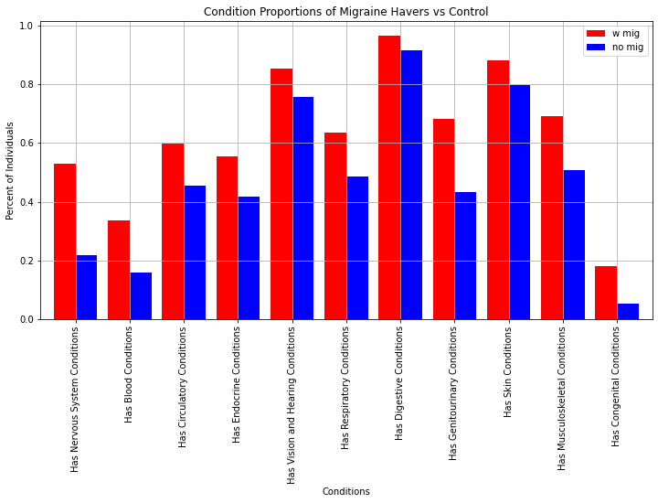

```python
conditions_prop.plot.bar(x='index',y=['w mig','no mig'],color=[ 'red', 'blue'], xlabel='Conditions',ylabel='Percent of Individuals', title='Condition Proportions of Migraine Havers vs Control', width=0.8, figsize=(12,6)).grid()
# Bar graph of conditions
```

**In every category, individuals with migraines were more likely to have comorbidities than participants without migraines. Someone with migraines is more than twice as likely to have another nervous system condition than someone without migraines**

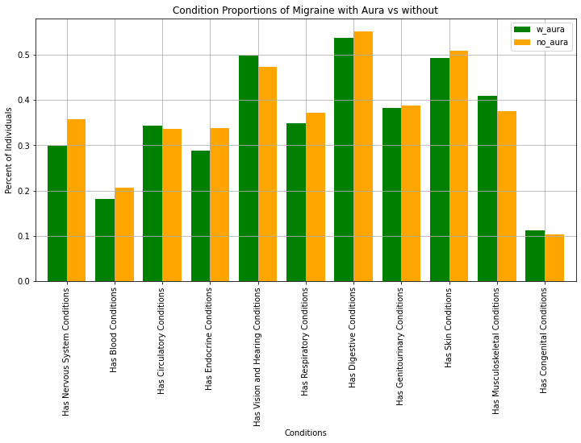

```python
conditions_prop.plot.bar(x='index',y=['w_aura','no_aura'],color=[ 'green', 'orange'], xlabel='Conditions',ylabel='Percent of Individuals', title='Condition Proportions of Migraine with Aura vs without', width=0.8, figsize=(12,6)).grid()
# Bar graph of conditions w and wout aura
```

**When looking at the prevelance of comorbidities in participants with vs without aura, there does not appear to be a relationship --> the frequency is approximately the same for both groupings across all 11 categories**

From there, we wanted to more specifically look at whether phenotypes and general traits had a statistical relationship with migraines

```python
# need dummies for Blood Types
phenotypes = pd.get_dummies(phenotypes,columns=['Blood Type'])
```

```python
phenotypes # dataframe with dummies for all (common) blood types
```

|  | Participant | Height (in) | Weight (lbs) | Blood Type_A + | Blood Type_A - | Blood Type_AB + | Blood Type_AB - | Blood Type_B + | Blood Type_B - | Blood Type_Don't know | Blood Type_O + | Blood Type_O - |
| --- | --- | --- | --- | --- | --- | --- | --- | --- | --- | --- | --- | --- |
| 0 | hu826751 | 6'2" | 188.0 | 0 | 0 | 1 | 0 | 0 | 0 | 0 | 0 | 0 |
| 1 | huDDCF88 | 5'10" | 159.0 | 0 | 0 | 0 | 0 | 0 | 0 | 0 | 1 | 0 |
| 2 | hu3DC5EA | 5'5" | 184.0 | 1 | 0 | 0 | 0 | 0 | 0 | 0 | 0 | 0 |
| 3 | hu008567 | 5'1" | 138.0 | 0 | 0 | 0 | 0 | 0 | 0 | 0 | 1 | 0 |
| 4 | hu98FFC6 | 5'5" | 230.0 | 1 | 0 | 0 | 0 | 0 | 0 | 0 | 0 | 0 |
| ... | ... | ... | ... | ... | ... | ... | ... | ... | ... | ... | ... | ... |
| 1096 | huF8913E | 5'6" | 185.0 | 0 | 0 | 0 | 0 | 0 | 0 | 0 | 1 | 0 |
| 1097 | hu794D40 | 5'9" | 170.0 | 1 | 0 | 0 | 0 | 0 | 0 | 0 | 0 | 0 |
| 1098 | huD8AD3F | 5'5" | 108.0 | 0 | 0 | 0 | 0 | 0 | 0 | 0 | 1 | 0 |
| 1099 | hu09787B | 5'9" | 233.0 | 0 | 0 | 0 | 0 | 0 | 0 | 0 | 1 | 0 |
| 1100 | huF5CD05 | 5'5" | 215.0 | 1 | 0 | 0 | 0 | 0 | 0 | 0 | 0 | 0 |

1101 rows × 12 columns

```python
# need height values to be type float
phenotypes['Height (in)'] = phenotypes['Height (in)'].str.replace("\"","")
phenotypes['Height (in)'] = phenotypes['Height (in)'].str.replace("'"," ")
phenotypes['Height (in)'] = [s.split(" ") for s in phenotypes['Height (in)']]
phenotypes['Height (in)'] = [float(value[0])*12 + float(value[1]) for value in phenotypes['Height (in)']]
```

```python
phenotypes
```

|  | Participant | Height (in) | Weight (lbs) | Blood Type_A + | Blood Type_A - | Blood Type_AB + | Blood Type_AB - | Blood Type_B + | Blood Type_B - | Blood Type_Don't know | Blood Type_O + | Blood Type_O - |
| --- | --- | --- | --- | --- | --- | --- | --- | --- | --- | --- | --- | --- |
| 0 | hu826751 | 74.0 | 188.0 | 0 | 0 | 1 | 0 | 0 | 0 | 0 | 0 | 0 |
| 1 | huDDCF88 | 70.0 | 159.0 | 0 | 0 | 0 | 0 | 0 | 0 | 0 | 1 | 0 |
| 2 | hu3DC5EA | 65.0 | 184.0 | 1 | 0 | 0 | 0 | 0 | 0 | 0 | 0 | 0 |
| 3 | hu008567 | 61.0 | 138.0 | 0 | 0 | 0 | 0 | 0 | 0 | 0 | 1 | 0 |
| 4 | hu98FFC6 | 65.0 | 230.0 | 1 | 0 | 0 | 0 | 0 | 0 | 0 | 0 | 0 |
| ... | ... | ... | ... | ... | ... | ... | ... | ... | ... | ... | ... | ... |
| 1096 | huF8913E | 66.0 | 185.0 | 0 | 0 | 0 | 0 | 0 | 0 | 0 | 1 | 0 |
| 1097 | hu794D40 | 69.0 | 170.0 | 1 | 0 | 0 | 0 | 0 | 0 | 0 | 0 | 0 |
| 1098 | huD8AD3F | 65.0 | 108.0 | 0 | 0 | 0 | 0 | 0 | 0 | 0 | 1 | 0 |
| 1099 | hu09787B | 69.0 | 233.0 | 0 | 0 | 0 | 0 | 0 | 0 | 0 | 1 | 0 |
| 1100 | huF5CD05 | 65.0 | 215.0 | 1 | 0 | 0 | 0 | 0 | 0 | 0 | 0 | 0 |

1101 rows × 12 columns

```python
traits = pd.get_dummies(traits,columns=['Sex/Gender','Race/ethnicity']) # Getting dummies for sex and race
```

```python
# remerging conditions with phenotypes and general traits // considering dummies now
all = conditions.merge(phenotypes,how='inner',on=['Participant'])
all = all.merge(traits,how='inner',on=['Participant'])
```

```python
all
```

|  | Participant | Nervous System Conditions | Circulatory System Conditions | Endocrine System Conditions | Blood Conditions | Visual and Hearing Conditions | Respiratory System Conditions | Digestive System Conditions | Genitourinary System Conditions | Skin Conditions | ... | Sex/Gender_sex: female; gender: non-binary | Race/ethnicity_American Indian | Race/ethnicity_Asian | Race/ethnicity_Asian, Hispanic or | Race/ethnicity_Asian, Native Hawaiian | Race/ethnicity_Black or African | Race/ethnicity_Hispanic or Latino | Race/ethnicity_Native Hawaiian | Race/ethnicity_No response | Race/ethnicity_White |
| --- | --- | --- | --- | --- | --- | --- | --- | --- | --- | --- | --- | --- | --- | --- | --- | --- | --- | --- | --- | --- | --- |
| 0 | hu620F18 | Migraine without aura | NaN | High cholesterol (hypercholesterolemia) | NaN | Myopia (Nearsightedness), Astigmatism, Floaters | NaN | Impacted tooth, Dental cavities, Gingivitis | NaN | Eczema, Allergic contact dermatitis, Skin tags | ... | 0 | 1 | 0 | 0 | 0 | 0 | 0 | 0 | 0 | 0 |
| 1 | hu620F18 | Migraine without aura | NaN | High cholesterol (hypercholesterolemia) | NaN | Myopia (Nearsightedness), Astigmatism, Floaters | NaN | Impacted tooth, Dental cavities, Gingivitis | NaN | Eczema, Allergic contact dermatitis, Skin tags | ... | 0 | 1 | 0 | 0 | 0 | 0 | 0 | 0 | 0 | 0 |
| 2 | hu620F18 | Migraine without aura | NaN | High cholesterol (hypercholesterolemia) | NaN | Myopia (Nearsightedness), Astigmatism, Floaters | NaN | Impacted tooth, Dental cavities, Gingivitis | NaN | Eczema, Allergic contact dermatitis, Skin tags | ... | 0 | 1 | 0 | 0 | 0 | 0 | 0 | 0 | 0 | 0 |
| 3 | hu3C0611 | Migraine without aura, Hereditary motor and se... | NaN | Thyroid nodule(s), Hypothyroidism, Hashimoto's... | Iron deficiency anemia | Floaters | Chronic tonsillitis, Allergic rhinitis, Asthma | Dental cavities | Kidney stones, Urinary tract infection (UTI) | Eczema, Keloids | ... | 0 | 0 | 0 | 0 | 0 | 0 | 0 | 0 | 0 | 1 |
| 4 | huE9B698 | NaN | NaN | Hypothyroidism | NaN | Myopia (Nearsightedness), Floaters | NaN | Impacted tooth, Dental cavities, Canker sores ... | NaN | Allergic contact dermatitis, Keloids, Skin tags | ... | 0 | 0 | 0 | 0 | 0 | 0 | 0 | 0 | 0 | 1 |
| ... | ... | ... | ... | ... | ... | ... | ... | ... | ... | ... | ... | ... | ... | ... | ... | ... | ... | ... | ... | ... | ... |
| 1127 | huD2D4B8 | NaN | Varicose veins | NaN | NaN | NaN | Asthma | NaN | NaN | Acne | ... | 0 | 0 | 0 | 0 | 0 | 0 | 0 | 0 | 0 | 1 |
| 1128 | huF8913E | Recurrent sleep paralysis, Restless legs syndr... | Hypertension, Hemorrhoids | Thyroid nodule(s), High cholesterol (hyperchol... | NaN | Myopia (Nearsightedness), Astigmatism, Floaters | Deviated septum, Chronic sinusitis, Allergic r... | Impacted tooth, Dental cavities, Canker sores ... | Urinary tract infection (UTI), Endometriosis | Dandruff, Acne | ... | 0 | 0 | 0 | 0 | 0 | 0 | 1 | 0 | 0 | 0 |
| 1129 | hu794D40 | Recurrent sleep paralysis | Hypertension | Thyroid nodule(s) | NaN | Age-related macular degeneration | Nasal polyps, Chronic sinusitis, Chronic tonsi... | Dental cavities, Temporomandibular joint (TMJ)... | Urinary tract infection (UTI) | Eczema, Allergic contact dermatitis, Rosacea, ... | ... | 0 | 0 | 0 | 0 | 0 | 0 | 0 | 0 | 0 | 1 |
| 1130 | huD8AD3F | Restless legs syndrome, Migraine with aura, Mi... | Angina, Cardiac arrhythmia | NaN | Iron deficiency anemia | Myopia (Nearsightedness), Tinnitus | NaN | Gastroesophageal reflux disease (GERD), Irrita... | Urinary tract infection (UTI), Ovarian cysts | Eczema, Allergic contact dermatitis, Hyperhidr... | ... | 0 | 0 | 0 | 0 | 0 | 0 | 0 | 0 | 0 | 1 |
| 1131 | hu09787B | NaN | Hypertension, Hemorrhoids | Thyroid nodule(s), Hypothyroidism, Hashimoto's... | Von Willebrand disease | Myopia (Nearsightedness), Astigmatism, Age-rel... | Chronic sinusitis | Dental cavities, Gallstones | Kidney stones | Dandruff, Hair loss (includes female and male ... | ... | 0 | 0 | 0 | 0 | 0 | 0 | 0 | 0 | 0 | 1 |

1132 rows × 63 columns

```python
all['Participant'].value_counts()
# need to drop dupes again

all = all.drop_duplicates(subset=['Participant'])
all = all.reset_index(drop=True)
```

```python
# EDA for traits
# mig havers by sex
male = [((all['Has Migraines'] == 1) & (all['Sex/Gender_Male']==1)).sum() / all['Has Migraines'].sum(),
        ((all['Has Migraines with Aura'] == 1) & (all['Sex/Gender_Male']==1)).sum() / all['Has Migraines with Aura'].sum(),
        ((all['Has Migraines without Aura'] == 1) & (all['Sex/Gender_Male']==1)).sum() / all['Has Migraines without Aura'].sum()]
female = [((all['Has Migraines'] == 1) & (all['Sex/Gender_Female']==1)).sum() / all['Has Migraines'].sum(),
          ((all['Has Migraines with Aura'] == 1) & (all['Sex/Gender_Female']==1)).sum() / all['Has Migraines with Aura'].sum(),
          ((all['Has Migraines without Aura'] == 1) & (all['Sex/Gender_Female']==1)).sum() / all['Has Migraines without Aura'].sum()]
```

```python
d={'male': male, 'female':female} #df for mig havers by sex
```

```python
sex_props = pd.DataFrame(data=d,index=['w mig','w_aura','no_aura'])
```

```python
sex_props = sex_props.reset_index()
```

```python
sex_props #proportions of participant sex considering migraine types
```

|  | index | male | female |
| --- | --- | --- | --- |
| 0 | w mig | 0.283505 | 0.706186 |
| 1 | w_aura | 0.227723 | 0.752475 |
| 2 | no_aura | 0.298246 | 0.684211 |

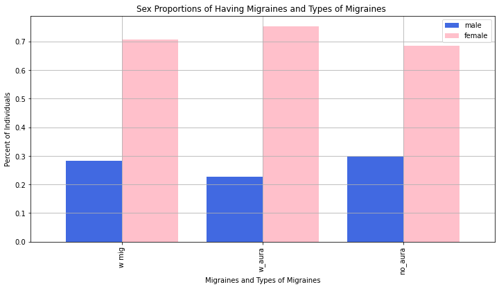

```python
sex_props.plot.bar(x='index',y=['male','female'],color=[ 'royalblue', 'pink'], xlabel='Migraines and Types of Migraines',ylabel='Percent of Individuals', title='Sex Proportions of Having Migraines and Types of Migraines ', width=0.8, figsize=(12,6)).grid()
```

**There appears to be a significant statistical relationship between biological sex and migraine occurance, with female participants making up close to 2/3 of the migraine having population**

From there, we wanted to see if blood type had any statistical relationship with migraines

```python
all.columns[28:37]
```

```
Index(['Blood Type_A +', 'Blood Type_A -', 'Blood Type_AB +',
       'Blood Type_AB -', 'Blood Type_B +', 'Blood Type_B -',
       'Blood Type_Don't know', 'Blood Type_O +', 'Blood Type_O -'],
      dtype='object')
```

```python
def prob_no_mig(cond): # Blood type proportions based on Migraine haver or not
  a = ((all['Has Migraines'] == 0) & (all[cond] == 1)).sum() / (all['Has Migraines'] == 0).sum()
  return a
def prob_w_mig(cond):
  b =((all['Has Migraines'] == 1) & (all[cond] == 1)).sum() / (all['Has Migraines'] == 1).sum()
  return b
```

```python
prob_w_list = [] # iterating through columns for blood types
for i in all.columns[28:37]:
  prob_w_list.append(prob_w_mig(i))
prob_no_list = []
for i in all.columns[28:37]:
  prob_no_list.append(prob_no_mig(i))
```

```python
def prob_no_aura(cond): # Blood type proportions based on Aura haver or not
  a = ((all['Has Migraines with Aura'] == 1) & (all[cond] == 1)).sum() / (all['Has Migraines'] == 1).sum()
  return a
def prob_w_aura(cond):
  b =((all['Has Migraines without Aura'] == 1) & (all[cond] == 1)).sum() / (all['Has Migraines'] == 1).sum()
  return b
```

```python
prob_w_aura_list = [] # iterating through columns for blood types
for i in all.columns[28:37]:
  prob_w_aura_list.append(prob_w_aura(i))
prob_no_aura_list = []
for i in all.columns[28:37]:
  prob_no_aura_list.append(prob_no_aura(i))
```

```python
d={'w mig': prob_w_list, 'no mig':prob_no_list, 'w_aura': prob_w_aura_list,'no_aura': prob_no_aura_list} #blood type probs dataframe
```

```python
blood_props = pd.DataFrame(data=d,index=all.columns[28:37])
```

```python
blood_props = blood_props.reset_index()
```

```python
blood_props #blood type vs type of migraine
```

|  | index | w mig | no mig | w_aura | no_aura |
| --- | --- | --- | --- | --- | --- |
| 0 | Blood Type_A + | 0.268041 | 0.256591 | 0.144330 | 0.154639 |
| 1 | Blood Type_A - | 0.041237 | 0.070299 | 0.041237 | 0.005155 |
| 2 | Blood Type_AB + | 0.061856 | 0.028120 | 0.036082 | 0.036082 |
| 3 | Blood Type_AB - | 0.015464 | 0.015817 | 0.005155 | 0.010309 |
| 4 | Blood Type_B + | 0.077320 | 0.086116 | 0.036082 | 0.051546 |
| 5 | Blood Type_B - | 0.015464 | 0.015817 | 0.010309 | 0.010309 |
| 6 | Blood Type_Don't know | 0.154639 | 0.184534 | 0.087629 | 0.077320 |
| 7 | Blood Type_O + | 0.278351 | 0.256591 | 0.170103 | 0.139175 |
| 8 | Blood Type_O - | 0.087629 | 0.086116 | 0.056701 | 0.036082 |

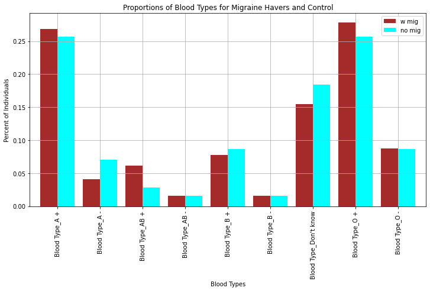

```python
blood_props.plot.bar(x='index',y=['w mig','no mig'],color=[ 'brown', 'aqua'], xlabel='Blood Types',ylabel='Percent of Individuals', title='Proportions of Blood Types for Migraine Havers and Control', width=0.8, figsize=(12,6)).grid()
```

**There does not appear to be a significant statistical relationship between having migraines and any specific blood type**

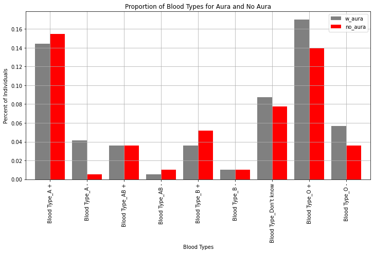

```python
blood_props.plot.bar(x='index',y=['w_aura','no_aura'],color=[ 'gray', 'red'], xlabel='Blood Types',ylabel='Percent of Individuals', title='Proportion of Blood Types for Aura and No Aura', width=0.8, figsize=(12,6)).grid()
```

**There is also a lack of significant relationship between blood type and migraines with aura vs without aura. Although there are larger differences between the control and experimental, this can be attributed to natural variance in a small data set**

We were also curious as to whether race/ethnicity had a relationship with migraine occurance

```python
all.columns[54:]
```

```
Index(['Race/ethnicity_American Indian', 'Race/ethnicity_Asian',
       'Race/ethnicity_Asian, Hispanic or',
       'Race/ethnicity_Asian, Native Hawaiian',
       'Race/ethnicity_Black or African', 'Race/ethnicity_Hispanic or Latino',
       'Race/ethnicity_Native Hawaiian', 'Race/ethnicity_No response',
       'Race/ethnicity_White'],
      dtype='object')
```

```python
def prob_no_mig(cond): # proportions for race per those with and without migraines
  a = ((all['Has Migraines'] == 0) & (all[cond] == 1)).sum() / (all[cond] == 1).sum()
  return a
def prob_w_mig(cond):
  b =((all['Has Migraines'] == 1) & (all[cond] == 1)).sum() / (all[cond] == 1).sum()
  return b
```

```python
prob_w_list = [] # iterating through columns for races
for i in all.columns[54:]:
  prob_w_list.append(prob_w_mig(i))
prob_no_list = []
for i in all.columns[54:]:
  prob_no_list.append(prob_no_mig(i))
```

```python
def prob_no_aura(cond): # aura types per race
  a = ((all['Has Migraines with Aura'] == 1) & (all[cond] == 1)).sum() / (all[cond] == 1).sum()
  return a
def prob_w_aura(cond):
  b =((all['Has Migraines without Aura'] == 1) & (all[cond] == 1)).sum() / (all[cond] == 1).sum()
  return b
```

```python
prob_w_aura_list = [] # iterating through columns for races
for i in all.columns[54:]:
  prob_w_aura_list.append(prob_w_aura(i))
prob_no_aura_list = []
for i in all.columns[54:]:
  prob_no_aura_list.append(prob_no_aura(i))
```

```python
d={'w mig': prob_w_list, 'no mig':prob_no_list, 'w_aura': prob_w_aura_list,'no_aura': prob_no_aura_list} # race props df
```

```python
race_props = pd.DataFrame(data=d,index=all.columns[54:])
```

```python
race_props = race_props.reset_index()
```

```python
race_props = race_props.dropna() # some races had very low values and no migs
```

```python
race_props #race/ethnicity vs migraines
```

|  | index | w mig | no mig | w_aura | no_aura |
| --- | --- | --- | --- | --- | --- |
| 0 | Race/ethnicity_American Indian | 0.419355 | 0.580645 | 0.258065 | 0.290323 |
| 1 | Race/ethnicity_Asian | 0.058824 | 0.941176 | 0.058824 | 0.000000 |
| 4 | Race/ethnicity_Black or African | 0.333333 | 0.666667 | 0.333333 | 0.000000 |
| 5 | Race/ethnicity_Hispanic or Latino | 0.269231 | 0.730769 | 0.230769 | 0.115385 |
| 6 | Race/ethnicity_Native Hawaiian | 0.000000 | 1.000000 | 0.000000 | 0.000000 |
| 7 | Race/ethnicity_No response | 0.500000 | 0.500000 | 0.000000 | 0.500000 |
| 8 | Race/ethnicity_White | 0.250368 | 0.749632 | 0.142857 | 0.129602 |

```python
race_props.drop(race_props.loc[race_props.w_aura < 0.00001].index, inplace=True) # getting rid of columns with 0s (low pops, unimportant)
```

```python
race_props
```

|  | index | w mig | no mig | w_aura | no_aura |
| --- | --- | --- | --- | --- | --- |
| 0 | Race/ethnicity_American Indian | 0.419355 | 0.580645 | 0.258065 | 0.290323 |
| 1 | Race/ethnicity_Asian | 0.058824 | 0.941176 | 0.058824 | 0.000000 |
| 4 | Race/ethnicity_Black or African | 0.333333 | 0.666667 | 0.333333 | 0.000000 |
| 5 | Race/ethnicity_Hispanic or Latino | 0.269231 | 0.730769 | 0.230769 | 0.115385 |
| 8 | Race/ethnicity_White | 0.250368 | 0.749632 | 0.142857 | 0.129602 |

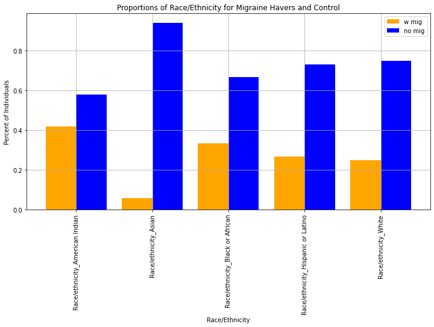

```python
race_props.plot.bar(x='index',y=['w mig','no mig'],color=[ 'orange', 'blue'], xlabel='Race/Ethnicity',ylabel='Percent of Individuals', title='Proportions of Race/Ethnicity for Migraine Havers and Control', width=0.8, figsize=(12,6)).grid()
```

**Based on this information alone, it would appear there is a statistical relationship between race and migraine. However, there is a higher proportion of white participants vs other races, which makes this metric a poor indicator**

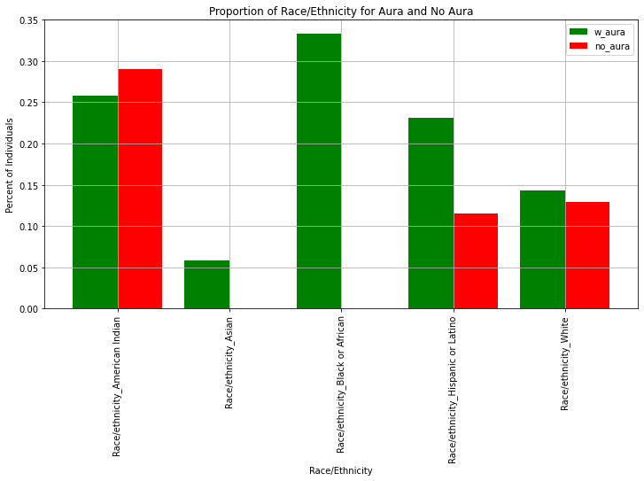

```python
race_props.plot.bar(x='index',y=['w_aura','no_aura'],color=[ 'green', 'red'], xlabel='Race/Ethnicity',ylabel='Percent of Individuals', title='Proportion of Race/Ethnicity for Aura and No Aura', width=0.8, figsize=(12,6)).grid()
```

**The same could be said for this plot --> although there appears to be a relationship between ethnicity and migraine with/without aura, the size and makeup of the dataset must be considered first**

### Exploring Genes

We also wanted to explore some relationships found in the genetic data. Within this section, we created additional dataframes and evaluated ratios of gene alleles in the population

```python
alleles
```

|  | Participant | Type of Migraine | Gene | Recessive or dominant | Homo/heterozyg | Mutation or variant? | Disease capacity | Has Migraine |
| --- | --- | --- | --- | --- | --- | --- | --- | --- |
| 0 | hu620F18 | Mig no aura | CBS-I278T | Recessive | Carrier (Heterozygous) | Mutation | Likely pathogenic | 1 |
| 1 | hu620F18 | Mig no aura | C3-R102G | Complex/Other | Heterozygous | Variant | Likely pathogenic | 1 |
| 2 | hu620F18 | Mig no aura | COL4A1-Q1334H | Dominant | Heterozygous | Variant | Likely pathogenic | 1 |
| 3 | hu620F18 | Mig no aura | MTRR-I49M | Recessive | Carrier (Heterozygous) | Variant | Likely pathogenic | 1 |
| 4 | hu620F18 | Mig no aura | rs5186 | Unknown | Heterozygous | Variant | Likely pathogenic | 1 |
| ... | ... | ... | ... | ... | ... | ... | ... | ... |
| 1253 | hu05FD49 | None | RPE65-N356 | / | heterozygous | Mutation - Frameshift | / | 0 |
| 1254 | hu05FD49 | None | PKD1-R2430 | / | heterozygous | Mutation - nonsense | / | 0 |
| 1255 | hu05FD49 | None | FLG-R3879 | / | heterozygous | Mutation - nonsense | / | 0 |
| 1256 | hu05FD49 | None | SBF2-H1549 | / | heterozygous | Mutation - nonsense | / | 0 |
| 1257 | hu05FD49 | None | NF2-K523 | / | heterozygous | Mutation - Frameshift | / | 0 |

1258 rows × 8 columns

```python
alleles.Gene.nunique() #there are 412 different genes in the df
```

```
412
```

```python
no_mig = alleles['Type of Migraine'].str.contains('None', case=False, na=False)
aura_mig = alleles['Type of Migraine'].str.contains('with aura', case=False, na=False)
no_aura_mig = alleles['Type of Migraine'].str.contains('no aura', case=False, na=False)
both_mig = alleles['Type of Migraine'].str.contains('Both', case=False, na=False)

none_df = alleles[no_mig]
aura_df = alleles[aura_mig]
no_aura_df = alleles[no_aura_mig]
both_df = alleles[both_mig]
```

```python
none_df.Gene.value_counts()
none_df.Participant.nunique() #40 people
aura_df.Participant.nunique() #49 people
no_aura_df.Participant.nunique() #38 people
both_df.Participant.nunique() #10 people
```

```
10
```

Out of the genetic information collected, there are alleles available for 40 participants with no migraines, 49 participants with migraine with aura, 38 people with migraine without aura, and 10 participants with both forms

```python
none_df2 = none_df[none_df.duplicated(subset=['Gene', 'Homo/heterozyg'], keep=False)]
aura_df2 = aura_df[aura_df.duplicated(subset=['Gene', 'Homo/heterozyg'], keep=False)]
no_aura_df2 = no_aura_df[no_aura_df.duplicated(subset=['Gene', 'Homo/heterozyg'], keep=False)]
both_df2 = both_df[both_df.duplicated(subset=['Gene', 'Homo/heterozyg'], keep=False)]
# keeping only the desired dataframes
```

[output not shown]

204 rows × 8 columns

```python
none_df2.Gene.value_counts()
```

```
MTRR-I49M         27
NEFL-S472         27
COL4A1-Q1334H     17
C3-R102G          13
rs5186            13
APOE-C130R         8
CBS-I278T          7
MBL2-G54D          6
MBL2-R52C          6
NPC1-W1122         4
SERPINA1-E288V     4
SYNE1-N1915        4
AMPD1-Q12X         4
APOA5-S19W         4
HABP2-G534E        3
PAX2-Y273          3
HFE-C282Y          3
TGM1-E520G         3
TTN-E190           3
KRT5-G138E         3
NOD2-R702W         3
ACAD8-S171C        3
CREBBP-P1878       2
PRPH-D141Y         2
SERPINA1-E366K     2
RYR1-P2002         2
HPS6-A597          2
SNCA-Y39           2
PHKB-M185I         2
LPL-N318S          2
ALG3-F200          2
PKP2-S140F         2
MSR1-R293X         2
SPG11-K1013E       2
CETP-A390P         2
THBD-A43T          2
CD40LG-G219R       2
PEX26-L153V        2
WFS1-R456H         2
SNCA-A69           2
Name: Gene, dtype: int64
```

```python
none_df2 = none_df2.drop('Disease capacity', axis = 1)
none_df2 = none_df2.drop('Recessive or dominant', axis = 1)
none_df2 = none_df2.drop('Mutation or variant?', axis = 1)
# dropping columns
#none_df2 = none_df2.drop('Unnamed: 7', axis = 1)
```

```python
def get_ratio(df, pattern):
  num = df.groupby(df[pattern].str.lower()).size()
  denom = len(df[pattern])
  return num/denom

# function to get the ratio of heterozygous to homozygous
```

```python
def gene_grab(df, listg):
  count = df.Gene.value_counts()
  for gene, num in count.iteritems():
    listg.append((gene, num))

  return listg

# function to collect the gene and its' relative frequency
```

```python
none_count = none_df2.Gene.value_counts()
none_genes = []

test = gene_grab(none_df2, none_genes)
test

# this creates a list with all the genes and freqs
```

```
[('MTRR-I49M', 27),
 ('NEFL-S472', 27),
 ('COL4A1-Q1334H', 17),
 ('C3-R102G', 13),
 ('rs5186', 13),
 ('APOE-C130R', 8),
 ('CBS-I278T', 7),
 ('MBL2-G54D', 6),
 ('MBL2-R52C', 6),
 ('NPC1-W1122', 4),
 ('SERPINA1-E288V', 4),
 ('SYNE1-N1915', 4),
 ('AMPD1-Q12X', 4),
 ('APOA5-S19W', 4),
 ('HABP2-G534E', 3),
 ('PAX2-Y273', 3),
 ('HFE-C282Y', 3),
 ('TGM1-E520G', 3),
 ('TTN-E190', 3),
 ('KRT5-G138E', 3),
 ('NOD2-R702W', 3),
 ('ACAD8-S171C', 3),
 ('CREBBP-P1878', 2),
 ('PRPH-D141Y', 2),
 ('SERPINA1-E366K', 2),
 ('RYR1-P2002', 2),
 ('HPS6-A597', 2),
 ('SNCA-Y39', 2),
 ('PHKB-M185I', 2),
 ('LPL-N318S', 2),
 ('ALG3-F200', 2),
 ('PKP2-S140F', 2),
 ('MSR1-R293X', 2),
 ('SPG11-K1013E', 2),
 ('CETP-A390P', 2),
 ('THBD-A43T', 2),
 ('CD40LG-G219R', 2),
 ('PEX26-L153V', 2),
 ('WFS1-R456H', 2),
 ('SNCA-A69', 2)]
```

```python
def get_freq(gene_freq_list, df, ratios_list):
  i = 0
  while i < len(gene_freq_list):
    gene = gene_freq_list[i][0]
    specific_gene_df = df[df['Gene'].str.contains(gene)]
    ratlist = []
    hold = get_ratio(specific_gene_df, 'Homo/heterozyg')
    for pattern, ratio in hold.iteritems():
      ratlist.append((pattern, ratio))
    ratios_list.append(ratlist)
    i += 1

  return ratios_list

# function that returns the allele types broken down individually
```

```python
breakdown_test = []
none_freqs = get_freq(test, none_df2, breakdown_test)

breakdown_test
```

```
[[('carrier (heterozygous)', 0.6296296296296297),
  ('homozygous', 0.37037037037037035)],
 [('homozygous', 1.0)],
 [('heterozygous', 0.7058823529411765), ('homozygous', 0.29411764705882354)],
 [('heterozygous', 1.0)],
 [('heterozygous', 0.8461538461538461), ('homozygous', 0.15384615384615385)],
 [('heterozygous', 1.0)],
 [('carrier (heterozygous)', 1.0)],
 [('carrier (heterozygous)', 1.0)],
 [('carrier (heterozygous)', 1.0)],
 [('heterozygous', 1.0)],
 [('carrier (heterozygous)', 1.0)],
 [('heterozygous', 1.0)],
 [('carrier (heterozygous)', 1.0)],
 [('heterozygous', 1.0)],
 [('heterozygous', 1.0)],
 [('heterozygous', 1.0)],
 [('carrier (heterozygous)', 1.0)],
 [('carrier (heterozygous)', 1.0)],
 [('heterozygous', 1.0)],
 [('heterozygous', 1.0)],
 [('heterozygous', 1.0)],
 [('carrier (heterozygous)', 1.0)],
 [('heterozygous', 1.0)],
 [('carrier (heterozygous)', 1.0)],
 [('carrier (heterozygous)', 1.0)],
 [('heterozygous', 1.0)],
 [('heterozygous', 1.0)],
 [('heterozygous', 1.0)],
 [('carrier (heterozygous)', 1.0)],
 [('heterozygous', 1.0)],
 [('heterozygous', 1.0)],
 [('heterozygous', 1.0)],
 [('heterozygous', 1.0)],
 [('carrier (heterozygous)', 1.0)],
 [('heterozygous', 1.0)],
 [('heterozygous', 1.0)],
 [('carrier (heterozygous)', 1.0)],
 [('carrier (heterozygous)', 1.0)],
 [('heterozygous', 1.0)],
 [('heterozygous', 1.0)]]
```

```python
total_none_set = []
for item in range(len(test)):
  gene = test[item][0]
  freq = test[item][1]
  ratios = breakdown_test[item]
  total_none_set.append((gene, freq, ratios))

total_none_set

# creating list with gene, freq, and allele type distrib
```

```
[('MTRR-I49M',
  27,
  [('carrier (heterozygous)', 0.6296296296296297),
   ('homozygous', 0.37037037037037035)]),
 ('NEFL-S472', 27, [('homozygous', 1.0)]),
 ('COL4A1-Q1334H',
  17,
  [('heterozygous', 0.7058823529411765), ('homozygous', 0.29411764705882354)]),
 ('C3-R102G', 13, [('heterozygous', 1.0)]),
 ('rs5186',
  13,
  [('heterozygous', 0.8461538461538461), ('homozygous', 0.15384615384615385)]),
 ('APOE-C130R', 8, [('heterozygous', 1.0)]),
 ('CBS-I278T', 7, [('carrier (heterozygous)', 1.0)]),
 ('MBL2-G54D', 6, [('carrier (heterozygous)', 1.0)]),
 ('MBL2-R52C', 6, [('carrier (heterozygous)', 1.0)]),
 ('NPC1-W1122', 4, [('heterozygous', 1.0)]),
 ('SERPINA1-E288V', 4, [('carrier (heterozygous)', 1.0)]),
 ('SYNE1-N1915', 4, [('heterozygous', 1.0)]),
 ('AMPD1-Q12X', 4, [('carrier (heterozygous)', 1.0)]),
 ('APOA5-S19W', 4, [('heterozygous', 1.0)]),
 ('HABP2-G534E', 3, [('heterozygous', 1.0)]),
 ('PAX2-Y273', 3, [('heterozygous', 1.0)]),
 ('HFE-C282Y', 3, [('carrier (heterozygous)', 1.0)]),
 ('TGM1-E520G', 3, [('carrier (heterozygous)', 1.0)]),
 ('TTN-E190', 3, [('heterozygous', 1.0)]),
 ('KRT5-G138E', 3, [('heterozygous', 1.0)]),
 ('NOD2-R702W', 3, [('heterozygous', 1.0)]),
 ('ACAD8-S171C', 3, [('carrier (heterozygous)', 1.0)]),
 ('CREBBP-P1878', 2, [('heterozygous', 1.0)]),
 ('PRPH-D141Y', 2, [('carrier (heterozygous)', 1.0)]),
 ('SERPINA1-E366K', 2, [('carrier (heterozygous)', 1.0)]),
 ('RYR1-P2002', 2, [('heterozygous', 1.0)]),
 ('HPS6-A597', 2, [('heterozygous', 1.0)]),
 ('SNCA-Y39', 2, [('heterozygous', 1.0)]),
 ('PHKB-M185I', 2, [('carrier (heterozygous)', 1.0)]),
 ('LPL-N318S', 2, [('heterozygous', 1.0)]),
 ('ALG3-F200', 2, [('heterozygous', 1.0)]),
 ('PKP2-S140F', 2, [('heterozygous', 1.0)]),
 ('MSR1-R293X', 2, [('heterozygous', 1.0)]),
 ('SPG11-K1013E', 2, [('carrier (heterozygous)', 1.0)]),
 ('CETP-A390P', 2, [('heterozygous', 1.0)]),
 ('THBD-A43T', 2, [('heterozygous', 1.0)]),
 ('CD40LG-G219R', 2, [('carrier (heterozygous)', 1.0)]),
 ('PEX26-L153V', 2, [('carrier (heterozygous)', 1.0)]),
 ('WFS1-R456H', 2, [('heterozygous', 1.0)]),
 ('SNCA-A69', 2, [('heterozygous', 1.0)])]
```

After collecting this information for people without migraines, the same process was repeated with the other dfs. The same functions were utilized

```python
aura_df2.Gene.value_counts()
```

```
MTRR-I49M         35
COL4A1-Q1334H     30
rs5186            21
APOE-C130R        14
C3-R102G          13
BEST1-S192        12
BEST1-Y245        12
MBL2-R52C         10
AMPD1-Q12X        10
MBL2-G54D          9
CETP-A390P         7
NEFL-S472          7
KRT5-G138E         5
KRT86-E402Q        5
PIGR-A580V         5
BTD-D444H          5
ACAD8-S171C        4
SERPINA1-E288V     4
VWF-S1506L         3
HABP2-G534E        3
RET-R231H          3
WFS1-R456H         3
KDR-C482R          3
HFE-S65C           3
SLC4A1-E40K        3
MPO-M251T          3
NOD2-G908R         3
KRT14-C18X         2
FCGR2B-I232T       2
RPGRIP1L-A229T     2
CFTR-S1235R        2
HFE-C282Y          2
MEFV-E148Q         2
MFN2-Q276R         2
APOA5-S19W         2
TTN-E190           2
COL9A3-R103W       2
PRF1-A91V          2
NOD2-R702W         2
ABCA4-G863A        2
ABCA4-A1038V       2
Name: Gene, dtype: int64
```

```python
aura_df2 = aura_df2.drop('Disease capacity', axis = 1)
aura_df2 = aura_df2.drop('Recessive or dominant', axis = 1)
aura_df2 = aura_df2.drop('Mutation or variant?', axis = 1)
#aura_df2 = aura_df2.drop('Unnamed: 7', axis = 1)
```

```python
aura_genes = []

ag_list = gene_grab(aura_df2, aura_genes)
ag_list
```

```
[('MTRR-I49M', 35),
 ('COL4A1-Q1334H', 30),
 ('rs5186', 21),
 ('APOE-C130R', 14),
 ('C3-R102G', 13),
 ('BEST1-S192', 12),
 ('BEST1-Y245', 12),
 ('MBL2-R52C', 10),
 ('AMPD1-Q12X', 10),
 ('MBL2-G54D', 9),
 ('CETP-A390P', 7),
 ('NEFL-S472', 7),
 ('KRT5-G138E', 5),
 ('KRT86-E402Q', 5),
 ('PIGR-A580V', 5),
 ('BTD-D444H', 5),
 ('ACAD8-S171C', 4),
 ('SERPINA1-E288V', 4),
 ('VWF-S1506L', 3),
 ('HABP2-G534E', 3),
 ('RET-R231H', 3),
 ('WFS1-R456H', 3),
 ('KDR-C482R', 3),
 ('HFE-S65C', 3),
 ('SLC4A1-E40K', 3),
 ('MPO-M251T', 3),
 ('NOD2-G908R', 3),
 ('KRT14-C18X', 2),
 ('FCGR2B-I232T', 2),
 ('RPGRIP1L-A229T', 2),
 ('CFTR-S1235R', 2),
 ('HFE-C282Y', 2),
 ('MEFV-E148Q', 2),
 ('MFN2-Q276R', 2),
 ('APOA5-S19W', 2),
 ('TTN-E190', 2),
 ('COL9A3-R103W', 2),
 ('PRF1-A91V', 2),
 ('NOD2-R702W', 2),
 ('ABCA4-G863A', 2),
 ('ABCA4-A1038V', 2)]
```

```python
aurafr = []
aura_freqs = get_freq(ag_list, aura_df2, aurafr)
aurafr
```

```
[[('carrier (heterozygous)', 0.7428571428571429),
  ('homozygous', 0.2571428571428571)],
 [('heterozygous', 0.6333333333333333), ('homozygous', 0.36666666666666664)],
 [('heterozygous', 0.7142857142857143), ('homozygous', 0.2857142857142857)],
 [('heterozygous', 0.8571428571428571), ('homozygous', 0.14285714285714285)],
 [('heterozygous', 0.8461538461538461), ('homozygous', 0.15384615384615385)],
 [('homozygous', 1.0)],
 [('homozygous', 1.0)],
 [('carrier (heterozygous)', 1.0)],
 [('carrier (heterozygous)', 1.0)],
 [('carrier (heterozygous)', 1.0)],
 [('heterozygous', 1.0)],
 [('homozygous', 1.0)],
 [('heterozygous', 1.0)],
 [('homozygous', 1.0)],
 [('heterozygous', 1.0)],
 [('carrier (heterozygous)', 1.0)],
 [('carrier (heterozygous)', 1.0)],
 [('carrier (heterozygous)', 1.0)],
 [('carrier (heterozygous)', 1.0)],
 [('heterozygous', 1.0)],
 [('heterozygous', 1.0)],
 [('heterozygous', 1.0)],
 [('heterozygous', 1.0)],
 [('carrier (heterozygous)', 1.0)],
 [('carrier (heterozygous)', 1.0)],
 [('carrier (heterozygous)', 1.0)],
 [('heterozygous', 1.0)],
 [('heterozygous', 1.0)],
 [('heterozygous', 1.0)],
 [('heterozygous', 1.0)],
 [('carrier (heterozygous)', 1.0)],
 [('carrier (heterozygous)', 1.0)],
 [('carrier (heterozygous)', 1.0)],
 [('heterozygous', 1.0)],
 [('heterozygous', 1.0)],
 [('heterozygous', 1.0)],
 [('heterozygous', 1.0)],
 [('heterozygous', 1.0)],
 [('heterozygous', 1.0)],
 [('carrier (heterozygous)', 1.0)],
 [('heterozygous', 1.0)]]
```

```python
total_aura_set = []
for item in range(len(ag_list)):
  gene = ag_list[item][0]
  freq = ag_list[item][1]
  ratios = aurafr[item]
  total_aura_set.append((gene, freq, ratios))

total_aura_set #full set of information for people with migraine with aura
```

```
[('MTRR-I49M',
  35,
  [('carrier (heterozygous)', 0.7428571428571429),
   ('homozygous', 0.2571428571428571)]),
 ('COL4A1-Q1334H',
  30,
  [('heterozygous', 0.6333333333333333), ('homozygous', 0.36666666666666664)]),
 ('rs5186',
  21,
  [('heterozygous', 0.7142857142857143), ('homozygous', 0.2857142857142857)]),
 ('APOE-C130R',
  14,
  [('heterozygous', 0.8571428571428571), ('homozygous', 0.14285714285714285)]),
 ('C3-R102G',
  13,
  [('heterozygous', 0.8461538461538461), ('homozygous', 0.15384615384615385)]),
 ('BEST1-S192', 12, [('homozygous', 1.0)]),
 ('BEST1-Y245', 12, [('homozygous', 1.0)]),
 ('MBL2-R52C', 10, [('carrier (heterozygous)', 1.0)]),
 ('AMPD1-Q12X', 10, [('carrier (heterozygous)', 1.0)]),
 ('MBL2-G54D', 9, [('carrier (heterozygous)', 1.0)]),
 ('CETP-A390P', 7, [('heterozygous', 1.0)]),
 ('NEFL-S472', 7, [('homozygous', 1.0)]),
 ('KRT5-G138E', 5, [('heterozygous', 1.0)]),
 ('KRT86-E402Q', 5, [('homozygous', 1.0)]),
 ('PIGR-A580V', 5, [('heterozygous', 1.0)]),
 ('BTD-D444H', 5, [('carrier (heterozygous)', 1.0)]),
 ('ACAD8-S171C', 4, [('carrier (heterozygous)', 1.0)]),
 ('SERPINA1-E288V', 4, [('carrier (heterozygous)', 1.0)]),
 ('VWF-S1506L', 3, [('carrier (heterozygous)', 1.0)]),
 ('HABP2-G534E', 3, [('heterozygous', 1.0)]),
 ('RET-R231H', 3, [('heterozygous', 1.0)]),
 ('WFS1-R456H', 3, [('heterozygous', 1.0)]),
 ('KDR-C482R', 3, [('heterozygous', 1.0)]),
 ('HFE-S65C', 3, [('carrier (heterozygous)', 1.0)]),
 ('SLC4A1-E40K', 3, [('carrier (heterozygous)', 1.0)]),
 ('MPO-M251T', 3, [('carrier (heterozygous)', 1.0)]),
 ('NOD2-G908R', 3, [('heterozygous', 1.0)]),
 ('KRT14-C18X', 2, [('heterozygous', 1.0)]),
 ('FCGR2B-I232T', 2, [('heterozygous', 1.0)]),
 ('RPGRIP1L-A229T', 2, [('heterozygous', 1.0)]),
 ('CFTR-S1235R', 2, [('carrier (heterozygous)', 1.0)]),
 ('HFE-C282Y', 2, [('carrier (heterozygous)', 1.0)]),
 ('MEFV-E148Q', 2, [('carrier (heterozygous)', 1.0)]),
 ('MFN2-Q276R', 2, [('heterozygous', 1.0)]),
 ('APOA5-S19W', 2, [('heterozygous', 1.0)]),
 ('TTN-E190', 2, [('heterozygous', 1.0)]),
 ('COL9A3-R103W', 2, [('heterozygous', 1.0)]),
 ('PRF1-A91V', 2, [('heterozygous', 1.0)]),
 ('NOD2-R702W', 2, [('heterozygous', 1.0)]),
 ('ABCA4-G863A', 2, [('carrier (heterozygous)', 1.0)]),
 ('ABCA4-A1038V', 2, [('heterozygous', 1.0)])]
```

```python
both_df2.Gene.value_counts()
```

```
MTRR-I49M         9
HFE-C282Y         5
KRT86-E402Q       4
COL4A1-Q1334H     4
APOA5-S19W        3
VWF-S1506L        3
MBL2-R52C         3
C3-R102G          3
SERPINA1-E366K    2
KRT5-G138E        2
CYP21A2-Q319X     2
MYH7-Q1334        2
MBL2-G54D         2
SERPINA1-E288V    2
RPGRIP1L-A229T    2
APC-Y486X         2
AMPD1-Q12X        2
PRF1-A91V         2
Name: Gene, dtype: int64
```

```python
both_count = both_df2.Gene.value_counts()
both_genes = []

bboth = gene_grab(both_df2, both_genes)
bboth
```

```
[('MTRR-I49M', 9),
 ('HFE-C282Y', 5),
 ('KRT86-E402Q', 4),
 ('COL4A1-Q1334H', 4),
 ('APOA5-S19W', 3),
 ('VWF-S1506L', 3),
 ('MBL2-R52C', 3),
 ('C3-R102G', 3),
 ('SERPINA1-E366K', 2),
 ('KRT5-G138E', 2),
 ('CYP21A2-Q319X', 2),
 ('MYH7-Q1334', 2),
 ('MBL2-G54D', 2),
 ('SERPINA1-E288V', 2),
 ('RPGRIP1L-A229T', 2),
 ('APC-Y486X', 2),
 ('AMPD1-Q12X', 2),
 ('PRF1-A91V', 2)]
```

```python
both_test = []
both_freqs = get_freq(bboth, both_df2, both_test)

both_test
```

```
[[('carrier (heterozygous)', 0.5555555555555556),
  ('homozygous', 0.4444444444444444)],
 [('carrier (heterozygous)', 1.0)],
 [('homozygous', 1.0)],
 [('heterozygous', 1.0)],
 [('heterozygous', 1.0)],
 [('carrier (heterozygous)', 1.0)],
 [('carrier (heterozygous)', 1.0)],
 [('heterozygous', 1.0)],
 [('carrier (heterozygous)', 1.0)],
 [('heterozygous', 1.0)],
 [('carrier (heterozygous)', 1.0)],
 [('heterozygous', 1.0)],
 [('carrier (heterozygous)', 1.0)],
 [('carrier (heterozygous)', 1.0)],
 [('heterozygous', 1.0)],
 [('heterozygous', 1.0)],
 [('carrier (heterozygous)', 1.0)],
 [('heterozygous', 1.0)]]
```

```python
total_both_set = []
for item in range(len(bboth)):
  gene = bboth[item][0]
  freq = bboth[item][1]
  ratios = both_test[item]
  total_both_set.append((gene, freq, ratios))

total_both_set # information for those with both forms of migraine
```

```
[('MTRR-I49M',
  9,
  [('carrier (heterozygous)', 0.5555555555555556),
   ('homozygous', 0.4444444444444444)]),
 ('HFE-C282Y', 5, [('carrier (heterozygous)', 1.0)]),
 ('KRT86-E402Q', 4, [('homozygous', 1.0)]),
 ('COL4A1-Q1334H', 4, [('heterozygous', 1.0)]),
 ('APOA5-S19W', 3, [('heterozygous', 1.0)]),
 ('VWF-S1506L', 3, [('carrier (heterozygous)', 1.0)]),
 ('MBL2-R52C', 3, [('carrier (heterozygous)', 1.0)]),
 ('C3-R102G', 3, [('heterozygous', 1.0)]),
 ('SERPINA1-E366K', 2, [('carrier (heterozygous)', 1.0)]),
 ('KRT5-G138E', 2, [('heterozygous', 1.0)]),
 ('CYP21A2-Q319X', 2, [('carrier (heterozygous)', 1.0)]),
 ('MYH7-Q1334', 2, [('heterozygous', 1.0)]),
 ('MBL2-G54D', 2, [('carrier (heterozygous)', 1.0)]),
 ('SERPINA1-E288V', 2, [('carrier (heterozygous)', 1.0)]),
 ('RPGRIP1L-A229T', 2, [('heterozygous', 1.0)]),
 ('APC-Y486X', 2, [('heterozygous', 1.0)]),
 ('AMPD1-Q12X', 2, [('carrier (heterozygous)', 1.0)]),
 ('PRF1-A91V', 2, [('heterozygous', 1.0)])]
```

```python
no_aura_df2.Gene.value_counts()
```

```
MTRR-I49M         29
rs5186            23
COL4A1-Q1334H     19
NEFL-S472         12
C3-R102G          11
AMPD1-Q12X        10
APOE-C130R        10
MBL2-G54D          8
BEST1-S192         8
BEST1-Y245         8
KRT86-E402Q        6
APOA5-S19W         6
MBL2-R52C          4
DMD-E2910V         3
NOD2-R702W         3
CYP21A2-Q319X      3
PRPH-D141Y         3
RP1-T373I          3
MEFV-P369S         3
CFTR-W1204X        2
VWF-S1506L         2
WFS1-R456H         2
ARSA-T274M         2
KRT5-G138E         2
PMP22-T118M        2
HFE-C282Y          2
APC-Y486X          2
CBS-I278T          2
KRT14-C18X         2
PMM2-V129M         2
ABCC6-R1164X       2
BTD-D444H          2
VCL-M1073          2
DOK7-S45L          2
RPGRIP1L-A229T     2
CETP-A390P         2
SPG11-K1013E       2
RET-R231H          2
Name: Gene, dtype: int64
```

```python
no_aura_count = no_aura_df2.Gene.value_counts()
no_aura_genes = []

noaur = gene_grab(no_aura_df2, no_aura_genes)
noaur
```

```
[('MTRR-I49M', 29),
 ('rs5186', 23),
 ('COL4A1-Q1334H', 19),
 ('NEFL-S472', 12),
 ('C3-R102G', 11),
 ('AMPD1-Q12X', 10),
 ('APOE-C130R', 10),
 ('MBL2-G54D', 8),
 ('BEST1-S192', 8),
 ('BEST1-Y245', 8),
 ('KRT86-E402Q', 6),
 ('APOA5-S19W', 6),
 ('MBL2-R52C', 4),
 ('DMD-E2910V', 3),
 ('NOD2-R702W', 3),
 ('CYP21A2-Q319X', 3),
 ('PRPH-D141Y', 3),
 ('RP1-T373I', 3),
 ('MEFV-P369S', 3),
 ('CFTR-W1204X', 2),
 ('VWF-S1506L', 2),
 ('WFS1-R456H', 2),
 ('ARSA-T274M', 2),
 ('KRT5-G138E', 2),
 ('PMP22-T118M', 2),
 ('HFE-C282Y', 2),
 ('APC-Y486X', 2),
 ('CBS-I278T', 2),
 ('KRT14-C18X', 2),
 ('PMM2-V129M', 2),
 ('ABCC6-R1164X', 2),
 ('BTD-D444H', 2),
 ('VCL-M1073', 2),
 ('DOK7-S45L', 2),
 ('RPGRIP1L-A229T', 2),
 ('CETP-A390P', 2),
 ('SPG11-K1013E', 2),
 ('RET-R231H', 2)]
```

```python
noaur_test = []
noaur_freqs = get_freq(noaur, no_aura_df2, noaur_test)

noaur_test
```

```
[[('carrier (heterozygous)', 0.5517241379310345),
  ('homozygous', 0.4482758620689655)],
 [('heterozygous', 0.9130434782608695), ('homozygous', 0.08695652173913043)],
 [('heterozygous', 0.8947368421052632), ('homozygous', 0.10526315789473684)],
 [('homozygous', 1.0)],
 [('heterozygous', 1.0)],
 [('carrier (heterozygous)', 0.8), ('homozygous', 0.2)],
 [('heterozygous', 1.0)],
 [('carrier (heterozygous)', 1.0)],
 [('homozygous', 1.0)],
 [('homozygous', 1.0)],
 [('homozygous', 1.0)],
 [('heterozygous', 1.0)],
 [('carrier (heterozygous)', 1.0)],
 [('heterozygous', 1.0)],
 [('heterozygous', 1.0)],
 [('carrier (heterozygous)', 1.0)],
 [('carrier (heterozygous)', 1.0)],
 [('carrier (heterozygous)', 1.0)],
 [('carrier (heterozygous)', 1.0)],
 [('homozygous', 1.0)],
 [('carrier (heterozygous)', 1.0)],
 [('heterozygous', 1.0)],
 [('carrier (heterozygous)', 1.0)],
 [('heterozygous', 1.0)],
 [('heterozygous', 1.0)],
 [('carrier (heterozygous)', 1.0)],
 [('heterozygous', 1.0)],
 [('carrier (heterozygous)', 1.0)],
 [('heterozygous', 1.0)],
 [('homozygous', 1.0)],
 [('heterozygous', 1.0)],
 [('carrier (heterozygous)', 1.0)],
 [('heterozygous', 1.0)],
 [('carrier (heterozygous)', 1.0)],
 [('heterozygous', 1.0)],
 [('heterozygous', 1.0)],
 [('carrier (heterozygous)', 1.0)],
 [('heterozygous', 1.0)]]
```

```python
total_noaur_set = []
for item in range(len(noaur)):
  gene = noaur[item][0]
  freq = noaur[item][1]
  ratios = noaur_test[item]
  total_noaur_set.append((gene, freq, ratios))

total_noaur_set # total information for people with migraine without aura
```

```
[('MTRR-I49M',
  29,
  [('carrier (heterozygous)', 0.5517241379310345),
   ('homozygous', 0.4482758620689655)]),
 ('rs5186',
  23,
  [('heterozygous', 0.9130434782608695), ('homozygous', 0.08695652173913043)]),
 ('COL4A1-Q1334H',
  19,
  [('heterozygous', 0.8947368421052632), ('homozygous', 0.10526315789473684)]),
 ('NEFL-S472', 12, [('homozygous', 1.0)]),
 ('C3-R102G', 11, [('heterozygous', 1.0)]),
 ('AMPD1-Q12X', 10, [('carrier (heterozygous)', 0.8), ('homozygous', 0.2)]),
 ('APOE-C130R', 10, [('heterozygous', 1.0)]),
 ('MBL2-G54D', 8, [('carrier (heterozygous)', 1.0)]),
 ('BEST1-S192', 8, [('homozygous', 1.0)]),
 ('BEST1-Y245', 8, [('homozygous', 1.0)]),
 ('KRT86-E402Q', 6, [('homozygous', 1.0)]),
 ('APOA5-S19W', 6, [('heterozygous', 1.0)]),
 ('MBL2-R52C', 4, [('carrier (heterozygous)', 1.0)]),
 ('DMD-E2910V', 3, [('heterozygous', 1.0)]),
 ('NOD2-R702W', 3, [('heterozygous', 1.0)]),
 ('CYP21A2-Q319X', 3, [('carrier (heterozygous)', 1.0)]),
 ('PRPH-D141Y', 3, [('carrier (heterozygous)', 1.0)]),
 ('RP1-T373I', 3, [('carrier (heterozygous)', 1.0)]),
 ('MEFV-P369S', 3, [('carrier (heterozygous)', 1.0)]),
 ('CFTR-W1204X', 2, [('homozygous', 1.0)]),
 ('VWF-S1506L', 2, [('carrier (heterozygous)', 1.0)]),
 ('WFS1-R456H', 2, [('heterozygous', 1.0)]),
 ('ARSA-T274M', 2, [('carrier (heterozygous)', 1.0)]),
 ('KRT5-G138E', 2, [('heterozygous', 1.0)]),
 ('PMP22-T118M', 2, [('heterozygous', 1.0)]),
 ('HFE-C282Y', 2, [('carrier (heterozygous)', 1.0)]),
 ('APC-Y486X', 2, [('heterozygous', 1.0)]),
 ('CBS-I278T', 2, [('carrier (heterozygous)', 1.0)]),
 ('KRT14-C18X', 2, [('heterozygous', 1.0)]),
 ('PMM2-V129M', 2, [('homozygous', 1.0)]),
 ('ABCC6-R1164X', 2, [('heterozygous', 1.0)]),
 ('BTD-D444H', 2, [('carrier (heterozygous)', 1.0)]),
 ('VCL-M1073', 2, [('heterozygous', 1.0)]),
 ('DOK7-S45L', 2, [('carrier (heterozygous)', 1.0)]),
 ('RPGRIP1L-A229T', 2, [('heterozygous', 1.0)]),
 ('CETP-A390P', 2, [('heterozygous', 1.0)]),
 ('SPG11-K1013E', 2, [('carrier (heterozygous)', 1.0)]),
 ('RET-R231H', 2, [('heterozygous', 1.0)])]
```

After this, a compiled df was made

```python
total_none_set
tot_none_df2 = pd.DataFrame(total_none_set, columns = ['Gene', 'Frequency', 'Alleles'])
tot_none_df2

total_aura_set
tot_aura_df2 = pd.DataFrame(total_aura_set, columns = ['Gene', 'Frequency', 'Alleles'])
tot_aura_df2

total_both_set
tot_both_df2 = pd.DataFrame(total_both_set, columns = ['Gene', 'Frequency', 'Alleles'])
tot_both_df2

total_noaur_set
tot_noaur_df2 = pd.DataFrame(total_noaur_set, columns = ['Gene', 'Frequency', 'Alleles'])
tot_noaur_df2

# all the lists being converted to individual dataframes
```

[output not shown]

```python
# merging into one large dataframe

none_and_aura = tot_none_df2.merge(tot_aura_df2, on="Gene", how="outer")
none_and_aura.columns = ["Gene","Freq: None", "Alleles: none", "Freq: Aura", "Alleles: Aura"]
none_and_aura

none_aura_both = none_and_aura.merge(tot_both_df2, on="Gene", how="outer")
none_aura_both.columns = ["Gene","Freq: None", "Alleles: none", "Freq: Aura", "Alleles: Aura", "Freq: Both", "Alleles: Both"]
none_aura_both

all_types_df2 = none_aura_both.merge(tot_noaur_df2, on="Gene", how="outer")
all_types_df2.columns = ["Gene","Freq: None", "Alleles: none", "Freq: Aura", "Alleles: Aura", "Freq: Both", "Alleles: Both", "Freq: No Aura", "Alleles: No aura"]
all_types_df2
```

[output not shown]

```python
#filling in the NaN values
all_types_df2['Freq: Aura'] = all_types_df2['Freq: Aura'].fillna(0.0)
all_types_df2['Freq: None'] = all_types_df2['Freq: None'].fillna(0.0)
all_types_df2['Freq: No Aura'] = all_types_df2['Freq: No Aura'].fillna(0.0)
all_types_df2['Freq: Both'] = all_types_df2['Freq: Both'].fillna(0.0)
all_types_df2
```

|  | Gene | Freq: None | Alleles: none | Freq: Aura | Alleles: Aura | Freq: Both | Alleles: Both | Freq: No Aura | Alleles: No aura |
| --- | --- | --- | --- | --- | --- | --- | --- | --- | --- |
| 0 | MTRR-I49M | 27.0 | [(carrier (heterozygous), 0.6296296296296297),... | 35.0 | [(carrier (heterozygous), 0.7428571428571429),... | 9.0 | [(carrier (heterozygous), 0.5555555555555556),... | 29.0 | [(carrier (heterozygous), 0.5517241379310345),... |
| 1 | NEFL-S472 | 27.0 | [(homozygous, 1.0)] | 7.0 | [(homozygous, 1.0)] | 0.0 | NaN | 12.0 | [(homozygous, 1.0)] |
| 2 | COL4A1-Q1334H | 17.0 | [(heterozygous, 0.7058823529411765), (homozygo... | 30.0 | [(heterozygous, 0.6333333333333333), (homozygo... | 4.0 | [(heterozygous, 1.0)] | 19.0 | [(heterozygous, 0.8947368421052632), (homozygo... |
| 3 | C3-R102G | 13.0 | [(heterozygous, 1.0)] | 13.0 | [(heterozygous, 0.8461538461538461), (homozygo... | 3.0 | [(heterozygous, 1.0)] | 11.0 | [(heterozygous, 1.0)] |
| 4 | rs5186 | 13.0 | [(heterozygous, 0.8461538461538461), (homozygo... | 21.0 | [(heterozygous, 0.7142857142857143), (homozygo... | 0.0 | NaN | 23.0 | [(heterozygous, 0.9130434782608695), (homozygo... |
| ... | ... | ... | ... | ... | ... | ... | ... | ... | ... |
| 70 | PMP22-T118M | 0.0 | NaN | 0.0 | NaN | 0.0 | NaN | 2.0 | [(heterozygous, 1.0)] |
| 71 | PMM2-V129M | 0.0 | NaN | 0.0 | NaN | 0.0 | NaN | 2.0 | [(homozygous, 1.0)] |
| 72 | ABCC6-R1164X | 0.0 | NaN | 0.0 | NaN | 0.0 | NaN | 2.0 | [(heterozygous, 1.0)] |
| 73 | VCL-M1073 | 0.0 | NaN | 0.0 | NaN | 0.0 | NaN | 2.0 | [(heterozygous, 1.0)] |
| 74 | DOK7-S45L | 0.0 | NaN | 0.0 | NaN | 0.0 | NaN | 2.0 | [(carrier (heterozygous), 1.0)] |

75 rows × 9 columns

The, various mathematical equations were applied to the frequencies. Ratios of gene frequency between all populations and proportions in each individual subset were considered

```python
all_freq = ['Freq: None', "Freq: Both", "Freq: Aura", "Freq: No Aura"]
all_types_df2['Total'] = all_types_df2[all_freq].sum(axis=1)

all_types_df2
```

|  | Gene | Freq: None | Alleles: none | Freq: Aura | Alleles: Aura | Freq: Both | Alleles: Both | Freq: No Aura | Alleles: No aura | Total |
| --- | --- | --- | --- | --- | --- | --- | --- | --- | --- | --- |
| 0 | MTRR-I49M | 27.0 | [(carrier (heterozygous), 0.6296296296296297),... | 35.0 | [(carrier (heterozygous), 0.7428571428571429),... | 9.0 | [(carrier (heterozygous), 0.5555555555555556),... | 29.0 | [(carrier (heterozygous), 0.5517241379310345),... | 100.0 |
| 1 | NEFL-S472 | 27.0 | [(homozygous, 1.0)] | 7.0 | [(homozygous, 1.0)] | 0.0 | NaN | 12.0 | [(homozygous, 1.0)] | 46.0 |
| 2 | COL4A1-Q1334H | 17.0 | [(heterozygous, 0.7058823529411765), (homozygo... | 30.0 | [(heterozygous, 0.6333333333333333), (homozygo... | 4.0 | [(heterozygous, 1.0)] | 19.0 | [(heterozygous, 0.8947368421052632), (homozygo... | 70.0 |
| 3 | C3-R102G | 13.0 | [(heterozygous, 1.0)] | 13.0 | [(heterozygous, 0.8461538461538461), (homozygo... | 3.0 | [(heterozygous, 1.0)] | 11.0 | [(heterozygous, 1.0)] | 40.0 |
| 4 | rs5186 | 13.0 | [(heterozygous, 0.8461538461538461), (homozygo... | 21.0 | [(heterozygous, 0.7142857142857143), (homozygo... | 0.0 | NaN | 23.0 | [(heterozygous, 0.9130434782608695), (homozygo... | 57.0 |
| ... | ... | ... | ... | ... | ... | ... | ... | ... | ... | ... |
| 70 | PMP22-T118M | 0.0 | NaN | 0.0 | NaN | 0.0 | NaN | 2.0 | [(heterozygous, 1.0)] | 2.0 |
| 71 | PMM2-V129M | 0.0 | NaN | 0.0 | NaN | 0.0 | NaN | 2.0 | [(homozygous, 1.0)] | 2.0 |
| 72 | ABCC6-R1164X | 0.0 | NaN | 0.0 | NaN | 0.0 | NaN | 2.0 | [(heterozygous, 1.0)] | 2.0 |
| 73 | VCL-M1073 | 0.0 | NaN | 0.0 | NaN | 0.0 | NaN | 2.0 | [(heterozygous, 1.0)] | 2.0 |
| 74 | DOK7-S45L | 0.0 | NaN | 0.0 | NaN | 0.0 | NaN | 2.0 | [(carrier (heterozygous), 1.0)] | 2.0 |

75 rows × 10 columns

```python
all_types_df2['None Ratio'] = all_types_df2["Freq: None"].apply(lambda x: x / 40)
all_types_df2['Aura Ratio'] = all_types_df2["Freq: Aura"].apply(lambda x: x / 49)
all_types_df2['No Aura Ratio'] = all_types_df2["Freq: No Aura"].apply(lambda x: x / 38)
all_types_df2['Both Ratio'] = all_types_df2["Freq: Both"].apply(lambda x: x / 10)
all_types_df2['All Ratio'] = all_types_df2["Total"].apply(lambda x: x / 137)
all_types_df2['All Mig Ratio'] = ((all_types_df2["Freq: Aura"] + all_types_df2["Freq: No Aura"] + all_types_df2["Freq: Both"]) / 97)

all_types_df2

# hyper specific dropping of columns with not enough information
moddf = all_types_df2.drop([74, 73, 72, 71, 70, 69, 68, 67, 66, 65, 64, 63, 62, 61, 60, 58, 57, 56, 0, 2, 3, 5, 6,9,1,8, 10, 11, 15, 17, 18, 22, 21, 23, 24, 25, 26, 27, 28, 29, 30, 31, 32 ])
moddf2 = moddf.drop([35, 36, 37, 38, 39, 55,20, 14,33, 34,13,  53,  16, 19, 47, 48, 49, 50, 51, 52, 59 ])
moddf2
```

|  | Gene | Freq: None | Alleles: none | Freq: Aura | Alleles: Aura | Freq: Both | Alleles: Both | Freq: No Aura | Alleles: No aura | Total | None Ratio | Aura Ratio | No Aura Ratio | Both Ratio | All Ratio | All Mig Ratio |
| --- | --- | --- | --- | --- | --- | --- | --- | --- | --- | --- | --- | --- | --- | --- | --- | --- |
| 4 | rs5186 | 13.0 | [(heterozygous, 0.8461538461538461), (homozygo... | 21.0 | [(heterozygous, 0.7142857142857143), (homozygo... | 0.0 | NaN | 23.0 | [(heterozygous, 0.9130434782608695), (homozygo... | 57.0 | 0.325 | 0.428571 | 0.605263 | 0.0 | 0.416058 | 0.453608 |
| 7 | MBL2-G54D | 6.0 | [(carrier (heterozygous), 1.0)] | 9.0 | [(carrier (heterozygous), 1.0)] | 2.0 | [(carrier (heterozygous), 1.0)] | 8.0 | [(carrier (heterozygous), 1.0)] | 25.0 | 0.150 | 0.183673 | 0.210526 | 0.2 | 0.182482 | 0.195876 |
| 12 | AMPD1-Q12X | 4.0 | [(carrier (heterozygous), 1.0)] | 10.0 | [(carrier (heterozygous), 1.0)] | 2.0 | [(carrier (heterozygous), 1.0)] | 10.0 | [(carrier (heterozygous), 0.8), (homozygous, 0... | 26.0 | 0.100 | 0.204082 | 0.263158 | 0.2 | 0.189781 | 0.226804 |
| 40 | BEST1-S192 | 0.0 | NaN | 12.0 | [(homozygous, 1.0)] | 0.0 | NaN | 8.0 | [(homozygous, 1.0)] | 20.0 | 0.000 | 0.244898 | 0.210526 | 0.0 | 0.145985 | 0.206186 |
| 41 | BEST1-Y245 | 0.0 | NaN | 12.0 | [(homozygous, 1.0)] | 0.0 | NaN | 8.0 | [(homozygous, 1.0)] | 20.0 | 0.000 | 0.244898 | 0.210526 | 0.0 | 0.145985 | 0.206186 |
| 42 | KRT86-E402Q | 0.0 | NaN | 5.0 | [(homozygous, 1.0)] | 4.0 | [(homozygous, 1.0)] | 6.0 | [(homozygous, 1.0)] | 15.0 | 0.000 | 0.102041 | 0.157895 | 0.4 | 0.109489 | 0.154639 |
| 43 | PIGR-A580V | 0.0 | NaN | 5.0 | [(heterozygous, 1.0)] | 0.0 | NaN | 0.0 | NaN | 5.0 | 0.000 | 0.102041 | 0.000000 | 0.0 | 0.036496 | 0.051546 |
| 44 | BTD-D444H | 0.0 | NaN | 5.0 | [(carrier (heterozygous), 1.0)] | 0.0 | NaN | 2.0 | [(carrier (heterozygous), 1.0)] | 7.0 | 0.000 | 0.102041 | 0.052632 | 0.0 | 0.051095 | 0.072165 |
| 45 | VWF-S1506L | 0.0 | NaN | 3.0 | [(carrier (heterozygous), 1.0)] | 3.0 | [(carrier (heterozygous), 1.0)] | 2.0 | [(carrier (heterozygous), 1.0)] | 8.0 | 0.000 | 0.061224 | 0.052632 | 0.3 | 0.058394 | 0.082474 |
| 46 | RET-R231H | 0.0 | NaN | 3.0 | [(heterozygous, 1.0)] | 0.0 | NaN | 2.0 | [(heterozygous, 1.0)] | 5.0 | 0.000 | 0.061224 | 0.052632 | 0.0 | 0.036496 | 0.051546 |
| 54 | RPGRIP1L-A229T | 0.0 | NaN | 2.0 | [(heterozygous, 1.0)] | 2.0 | [(heterozygous, 1.0)] | 2.0 | [(heterozygous, 1.0)] | 6.0 | 0.000 | 0.040816 | 0.052632 | 0.2 | 0.043796 | 0.061856 |

Note: In order to create a graphable dataframe, we dropped a number of genes that had overall frequencies of less than 5 and/or low frequencies with a similar distribution in the control and migraine populations.

We dropped these manually, which is why there are a wide array of columns dropped above. Doing this project again, we would have likely developed a better methodology

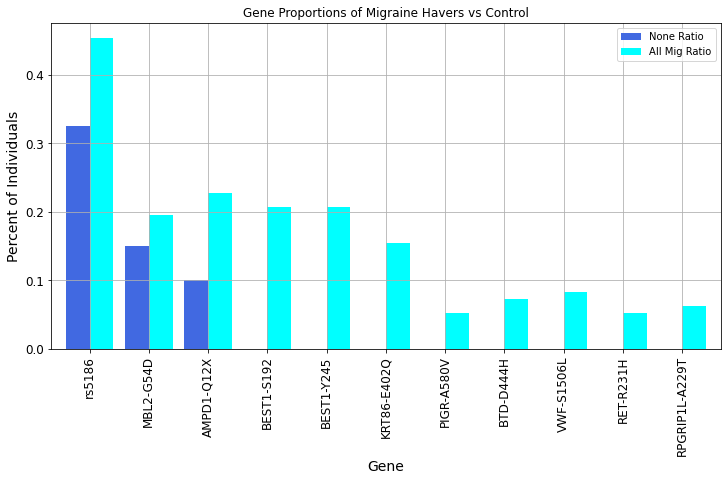

```python
import sklearn
assert sklearn.__version__ >= "0.20"

import numpy as np
import os

%matplotlib inline
import matplotlib as mpl
import matplotlib.pyplot as plt
mpl.rc('axes', labelsize=14)
mpl.rc('xtick', labelsize=12)
mpl.rc('ytick', labelsize=12)


moddf2.plot.bar(x='Gene', y=['None Ratio', 'All Mig Ratio'], color=[ 'royalblue', 'aqua'], ylabel='Percent of Individuals', title='Gene Proportions of Migraine Havers vs Control', width=0.8, figsize=(12,6)).grid()
#sns.catplot(data=moddf2, x="Gene", y=["None Ratio", "All Mig Ratio"])
```

**Within the set of significant alleles, there are a number of genes that are present in migraine populations, but not in the control group. Each column has at least 5 occurances of the gene across the board. These could possibly relate to migraines, or may be indicative of a scientific process outside the scope of our EDA**

# **Part 3: Modeling**

For the project, we decided we wanted to created two different models.

1. Can we predict whether someone has a specific comorbidity (i.e. a condition in one of the 11 subsets) based on whether or not they have migraines?
2. Can we predict whether someone has migraines using genomic data?

### Comorbidity Based

```python
all_features = ['Has Migraines', 'Has Migraines with Aura',
       'Has Migraines without Aura','Height (in)', 'Weight (lbs)', 'Blood Type_A +', 'Blood Type_A -',
       'Blood Type_AB +', 'Blood Type_AB -', 'Blood Type_B +',
       'Blood Type_B -', 'Blood Type_Don\'t know', 'Blood Type_O +',
       'Blood Type_O -', 'Sex/Gender_Female',
       'Sex/Gender_Male','Race/ethnicity_American Indian', 'Race/ethnicity_Asian',
       'Race/ethnicity_Black or African', 'Race/ethnicity_Hispanic or Latino',
       'Race/ethnicity_White'] # features to test
```

```python
#knn for system that is seemingly highly correlated with having migraines (nervous) with and without migs
def knn_nerv(k):
    model = KNeighborsClassifier(n_neighbors = k)
    scaler=StandardScaler()
    vec = DictVectorizer(sparse=False)
    pipeline = Pipeline([
        ("vec",vec),
        ("scaler", scaler),
        ("model", model)
    ])

    X_train = all[all_features]
    y_train = all['Has Nervous System Conditions']
    X_train=X_train.to_dict(orient="records")

    return (cross_val_score(pipeline, X_train, y_train, cv=5,scoring="accuracy").mean())
def knn_nerv_no_mig(k):
    model = KNeighborsClassifier(n_neighbors = k)
    scaler=StandardScaler()
    vec = DictVectorizer(sparse=False)
    pipeline = Pipeline([
        ("vec",vec),
        ("scaler", scaler),
        ("model", model)
    ])

    X_train = all[all_features[3:]]
    y_train = all['Has Nervous System Conditions']
    X_train=X_train.to_dict(orient="records")

    return (cross_val_score(pipeline, X_train, y_train, cv=5,scoring="accuracy").mean())
```

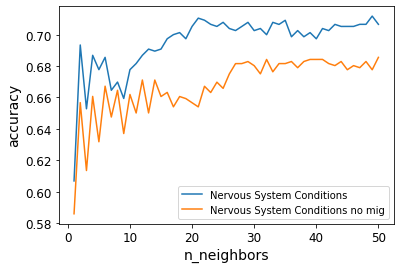

```python
ks = pd.Series(range(1, 51))
ks.index = range(1, 51)
nerv = ks.apply(knn_nerv)
nerv_no_mig = ks.apply(knn_nerv_no_mig)
plt.plot(nerv,label='Nervous System Conditions')
plt.plot(nerv_no_mig,label='Nervous System Conditions no mig')
plt.xlabel('n_neighbors')
plt.ylabel('accuracy')
plt.legend()
# as you can see migraines are correlated to prediction accuracy for nervous system conditions
```

**This model indicates that knowing whether someone has migraines or not leads to increased accuracy in predicting whether someone has a nervous system condition (other than migraines). This shows that there is likely a statistical relationship between migraines and the ability to predict comorbid neurological syndromes**

```python
#knn for system that is seemingly not highly correlated with having migraines (digestive) with and without migs
def knn_dig(k):
    model = KNeighborsClassifier(n_neighbors = k)
    scaler=StandardScaler()
    vec = DictVectorizer(sparse=False)
    pipeline = Pipeline([
        ("vec",vec),
        ("scaler", scaler),
        ("model", model)
    ])

    X_train = all[all_features]
    y_train = all['Has Digestive Conditions']
    X_train=X_train.to_dict(orient="records")

    return (cross_val_score(pipeline, X_train, y_train, cv=5,scoring="accuracy").mean())
def knn_dig_no_mig(k):
    model = KNeighborsClassifier(n_neighbors = k)
    scaler=StandardScaler()
    vec = DictVectorizer(sparse=False)
    pipeline = Pipeline([
        ("vec",vec),
        ("scaler", scaler),
        ("model", model)
    ])

    X_train = all[all_features[3:]]
    y_train = all['Has Digestive Conditions']
    X_train=X_train.to_dict(orient="records")

    return (cross_val_score(pipeline, X_train, y_train, cv=5,scoring="accuracy").mean())
```

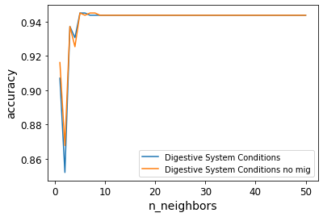

```python
ks = pd.Series(range(1, 51))
ks.index = range(1, 51)
dig = ks.apply(knn_dig)
dig_no_mig = ks.apply(knn_dig_no_mig)
plt.plot(dig,label='Digestive System Conditions')
plt.plot(dig_no_mig,label='Digestive System Conditions no mig')
plt.xlabel('n_neighbors')
plt.ylabel('accuracy')
plt.legend()
# as you can see removing migraines does not have a significant effect on accuracy for predicting digestive system conditions
```

**In this model, it is evident that knowing whether someone has migraines or not is not helpful information for predicting whether someone has a digestive system condition. This is not very successful and shows a lack of relationship between migraines and digestive comorbidities. This is likely the case for other conditions.**

### Gene Based

We started by rereading the alleles dataframe to ensure there were no issues with the dataset

```python
alleles = pd.read_excel('vari.xlsx') # genetic data
```

```python
alleles = alleles.drop('Unnamed: 7',axis=1) # dropping unnecessary data
```

```python
alleles['Has Migraine'] = alleles['Type of Migraine'] != 'None' # getting binary migraine columns
alleles['Has Migraine'] = alleles['Has Migraine'].map({True: 1, False: 0})
```

```python
alleles['Has Migraine with aura'] = alleles['Type of Migraine'] == 'Mig with aura'
alleles['Has Migraine with aura'] = alleles['Has Migraine with aura'].map({True: 1, False: 0})
alleles['Has Migraine without aura'] = alleles['Type of Migraine'] == 'Mig no aura'
alleles['Has Migraine without aura'] = alleles['Has Migraine without aura'].map({True: 1, False: 0})
```

```python
alleles
```

|  | Participant | Type of Migraine | Gene | Recessive or dominant | Homo/heterozyg | Mutation or variant? | Disease capacity | Has Migraine | Has Migraine with aura | Has Migraine without aura |
| --- | --- | --- | --- | --- | --- | --- | --- | --- | --- | --- |
| 0 | hu620F18 | Mig no aura | CBS-I278T | Recessive | Carrier (Heterozygous) | Mutation | Likely pathogenic | 1 | 0 | 1 |
| 1 | hu620F18 | Mig no aura | C3-R102G | Complex/Other | Heterozygous | Variant | Likely pathogenic | 1 | 0 | 1 |
| 2 | hu620F18 | Mig no aura | COL4A1-Q1334H | Dominant | Heterozygous | Variant | Likely pathogenic | 1 | 0 | 1 |
| 3 | hu620F18 | Mig no aura | MTRR-I49M | Recessive | Carrier (Heterozygous) | Variant | Likely pathogenic | 1 | 0 | 1 |
| 4 | hu620F18 | Mig no aura | rs5186 | Unknown | Heterozygous | Variant | Likely pathogenic | 1 | 0 | 1 |
| ... | ... | ... | ... | ... | ... | ... | ... | ... | ... | ... |
| 1256 | hu05FD49 | None | RPE65-N356 | / | heterozygous | Mutation - Frameshift | / | 0 | 0 | 0 |
| 1257 | hu05FD49 | None | PKD1-R2430 | / | heterozygous | Mutation - nonsense | / | 0 | 0 | 0 |
| 1258 | hu05FD49 | None | FLG-R3879 | / | heterozygous | Mutation - nonsense | / | 0 | 0 | 0 |
| 1259 | hu05FD49 | None | SBF2-H1549 | / | heterozygous | Mutation - nonsense | / | 0 | 0 | 0 |
| 1260 | hu05FD49 | None | NF2-K523 | / | heterozygous | Mutation - Frameshift | / | 0 | 0 | 0 |

1261 rows × 10 columns

```python
feat = ['Gene','Recessive or dominant','Homo/heterozyg','Mutation or variant?','Disease capacity'] # test cols
```

```python
# testing which features are most relevant to accurately predicting whether someone has migraines
def knn_full(n):
  model = KNeighborsClassifier(n_neighbors=n)
  scaler=StandardScaler()
  vec = DictVectorizer(sparse=False)
  pipeline = Pipeline([
        ("vec",vec),
        ("scaler", scaler),
        ("model", model)
    ])
  X_train = alleles[feat]
  y_train = alleles['Has Migraine']
  X_train=X_train.to_dict(orient="records")
  return (cross_val_score(pipeline, X_train, y_train, cv=5,scoring="accuracy").mean())
def knn_no_gene(n):
    model = KNeighborsClassifier(n_neighbors=n)
    scaler=StandardScaler()
    vec = DictVectorizer(sparse=False)
    pipeline = Pipeline([
        ("vec",vec),
        ("scaler", scaler),
        ("model", model)
    ])
    X_train = alleles[feat[1:]]
    y_train = alleles['Has Migraine']
    X_train=X_train.to_dict(orient="records")
    return (cross_val_score(pipeline, X_train, y_train, cv=5,scoring="accuracy").mean())
def knn_no_rec_dom(n):
    model = KNeighborsClassifier(n_neighbors=n)
    scaler=StandardScaler()
    vec = DictVectorizer(sparse=False)
    pipeline = Pipeline([
        ("vec",vec),
        ("scaler", scaler),
        ("model", model)
    ])
    X_train = alleles[['Gene','Homo/heterozyg','Mutation or variant?','Disease capacity']]
    y_train = alleles['Has Migraine']
    X_train=X_train.to_dict(orient="records")
    return (cross_val_score(pipeline, X_train, y_train, cv=5,scoring="accuracy").mean())
def knn_no_homo_hetero(n):
    model = KNeighborsClassifier(n_neighbors=n)
    scaler=StandardScaler()
    vec = DictVectorizer(sparse=False)
    pipeline = Pipeline([
        ("vec",vec),
        ("scaler", scaler),
        ("model", model)
    ])
    X_train = alleles[['Gene','Recessive or dominant','Mutation or variant?','Disease capacity']]
    y_train = alleles['Has Migraine']
    X_train=X_train.to_dict(orient="records")
    return (cross_val_score(pipeline, X_train, y_train, cv=5,scoring="accuracy").mean())
def knn_no_mutate(n):
    model = KNeighborsClassifier(n_neighbors=n)
    scaler=StandardScaler()
    vec = DictVectorizer(sparse=False)
    pipeline = Pipeline([
        ("vec",vec),
        ("scaler", scaler),
        ("model", model)
    ])
    X_train = alleles[['Gene','Homo/heterozyg','Recessive or dominant','Disease capacity']]
    y_train = alleles['Has Migraine']
    X_train=X_train.to_dict(orient="records")
    return (cross_val_score(pipeline, X_train, y_train, cv=5,scoring="accuracy").mean())
def knn_no_disease(n):
    model = KNeighborsClassifier(n_neighbors=n)
    scaler=StandardScaler()
    vec = DictVectorizer(sparse=False)
    pipeline = Pipeline([
        ("vec",vec),
        ("scaler", scaler),
        ("model", model)
    ])
    X_train = alleles[['Gene','Homo/heterozyg','Mutation or variant?','Recessive or dominant']]
    y_train = alleles['Has Migraine']
    X_train=X_train.to_dict(orient="records")
    return (cross_val_score(pipeline, X_train, y_train, cv=5,scoring="accuracy").mean())
```

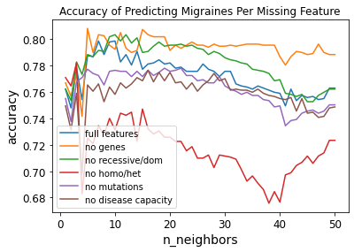

```python
ks = pd.Series(range(1, 51))
ks.index = range(1, 51)
full = ks.apply(knn_full)
no_gene = ks.apply(knn_no_gene)
no_rec_dom = ks.apply(knn_no_rec_dom)
no_homo_hetero = ks.apply(knn_no_homo_hetero)
no_mutate = ks.apply(knn_no_mutate)
no_disease = ks.apply(knn_no_disease)
plt.plot(full,label = 'full features')
plt.plot(no_gene,label = 'no genes')
plt.plot(no_rec_dom,label = 'no recessive/dom')
plt.plot(no_homo_hetero,label = 'no homo/het')
plt.plot(no_mutate,label = 'no mutations')
plt.plot(no_disease,label = 'no disease capacity')
plt.xlabel('n_neighbors')
plt.ylabel('accuracy')
plt.title('Accuracy of Predicting Migraines Per Missing Feature')
plt.legend()
# it seems that removing homo/hetero significantly impacts the models ability to predict whether someone has migraines
# most accurate disregards gene names but keeps other data
```

**This model used genomic information (from the dataframe) to predict whether someone had migraines or not. It appears that eliminating the genes themselves (no genes) actually has a positive relationship with accuracy! However, eliminating whether a gene is homozygous or heterozygous decreases accuracy, highlighting it has a more significant statistical relationship with the ability to predict migraines**

```python
# testing which features are most relevant to accurately predicting whether someone has migraines with aura

def knn_full(n):
  model = KNeighborsClassifier(n_neighbors=n)
  scaler=StandardScaler()
  vec = DictVectorizer(sparse=False)
  pipeline = Pipeline([
        ("vec",vec),
        ("scaler", scaler),
        ("model", model)
    ])
  X_train = alleles[feat]
  y_train = alleles['Has Migraine with aura']
  X_train=X_train.to_dict(orient="records")
  return (cross_val_score(pipeline, X_train, y_train, cv=5,scoring="accuracy").mean())
def knn_no_gene(n):
    model = KNeighborsClassifier(n_neighbors=n)
    scaler=StandardScaler()
    vec = DictVectorizer(sparse=False)
    pipeline = Pipeline([
        ("vec",vec),
        ("scaler", scaler),
        ("model", model)
    ])
    X_train = alleles[feat[1:]]
    y_train = alleles['Has Migraine with aura']
    X_train=X_train.to_dict(orient="records")
    return (cross_val_score(pipeline, X_train, y_train, cv=5,scoring="accuracy").mean())
def knn_no_rec_dom(n):
    model = KNeighborsClassifier(n_neighbors=n)
    scaler=StandardScaler()
    vec = DictVectorizer(sparse=False)
    pipeline = Pipeline([
        ("vec",vec),
        ("scaler", scaler),
        ("model", model)
    ])
    X_train = alleles[['Gene','Homo/heterozyg','Mutation or variant?','Disease capacity']]
    y_train = alleles['Has Migraine with aura']
    X_train=X_train.to_dict(orient="records")
    return (cross_val_score(pipeline, X_train, y_train, cv=5,scoring="accuracy").mean())
def knn_no_homo_hetero(n):
    model = KNeighborsClassifier(n_neighbors=n)
    scaler=StandardScaler()
    vec = DictVectorizer(sparse=False)
    pipeline = Pipeline([
        ("vec",vec),
        ("scaler", scaler),
        ("model", model)
    ])
    X_train = alleles[['Gene','Recessive or dominant','Mutation or variant?','Disease capacity']]
    y_train = alleles['Has Migraine with aura']
    X_train=X_train.to_dict(orient="records")
    return (cross_val_score(pipeline, X_train, y_train, cv=5,scoring="accuracy").mean())
def knn_no_mutate(n):
    model = KNeighborsClassifier(n_neighbors=n)
    scaler=StandardScaler()
    vec = DictVectorizer(sparse=False)
    pipeline = Pipeline([
        ("vec",vec),
        ("scaler", scaler),
        ("model", model)
    ])
    X_train = alleles[['Gene','Homo/heterozyg','Recessive or dominant','Disease capacity']]
    y_train = alleles['Has Migraine with aura']
    X_train=X_train.to_dict(orient="records")
    return (cross_val_score(pipeline, X_train, y_train, cv=5,scoring="accuracy").mean())
def knn_no_disease(n):
    model = KNeighborsClassifier(n_neighbors=n)
    scaler=StandardScaler()
    vec = DictVectorizer(sparse=False)
    pipeline = Pipeline([
        ("vec",vec),
        ("scaler", scaler),
        ("model", model)
    ])
    X_train = alleles[['Gene','Homo/heterozyg','Mutation or variant?','Recessive or dominant']]
    y_train = alleles['Has Migraine with aura']
    X_train=X_train.to_dict(orient="records")
    return (cross_val_score(pipeline, X_train, y_train, cv=5,scoring="accuracy").mean())
```

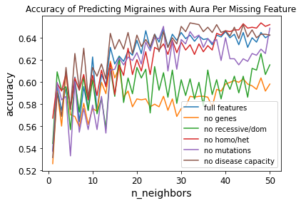

```python
ks = pd.Series(range(1, 51))
ks.index = range(1, 51)
full = ks.apply(knn_full)
no_gene = ks.apply(knn_no_gene)
no_rec_dom = ks.apply(knn_no_rec_dom)
no_homo_hetero = ks.apply(knn_no_homo_hetero)
no_mutate = ks.apply(knn_no_mutate)
no_disease = ks.apply(knn_no_disease)
plt.plot(full,label = 'full features')
plt.plot(no_gene,label = 'no genes')
plt.plot(no_rec_dom,label = 'no recessive/dom')
plt.plot(no_homo_hetero,label = 'no homo/het')
plt.plot(no_mutate,label = 'no mutations')
plt.plot(no_disease,label = 'no disease capacity')
plt.xlabel('n_neighbors')
plt.ylabel('accuracy')
plt.title('Accuracy of Predicting Migraines with Aura Per Missing Feature')
plt.legend()
# Genes and recessive/ dominant seem most important to predicting this type of migraine.
```

**When specifically predicting whether someone has migraines with aura, it appears that more neighbors increases accuracy. In this case, removing genes led to the largest decrease in accuracy. This is supported by the chart from the EDA section highlighting gene variance in only migraine havers; however, there are a number of variables that impact this conclusion**

```python
# testing which features are most relevant to accurately predicting whether someone has migraines without aura

def knn_full(n):
  model = KNeighborsClassifier(n_neighbors=n)
  scaler=StandardScaler()
  vec = DictVectorizer(sparse=False)
  pipeline = Pipeline([
        ("vec",vec),
        ("scaler", scaler),
        ("model", model)
    ])
  X_train = alleles[feat]
  y_train = alleles['Has Migraine without aura']
  X_train=X_train.to_dict(orient="records")
  return (cross_val_score(pipeline, X_train, y_train, cv=5,scoring="accuracy").mean())
def knn_no_gene(n):
    model = KNeighborsClassifier(n_neighbors=n)
    scaler=StandardScaler()
    vec = DictVectorizer(sparse=False)
    pipeline = Pipeline([
        ("vec",vec),
        ("scaler", scaler),
        ("model", model)
    ])
    X_train = alleles[feat[1:]]
    y_train = alleles['Has Migraine without aura']
    X_train=X_train.to_dict(orient="records")
    return (cross_val_score(pipeline, X_train, y_train, cv=5,scoring="accuracy").mean())
def knn_no_rec_dom(n):
    model = KNeighborsClassifier(n_neighbors=n)
    scaler=StandardScaler()
    vec = DictVectorizer(sparse=False)
    pipeline = Pipeline([
        ("vec",vec),
        ("scaler", scaler),
        ("model", model)
    ])
    X_train = alleles[['Gene','Homo/heterozyg','Mutation or variant?','Disease capacity']]
    y_train = alleles['Has Migraine without aura']
    X_train=X_train.to_dict(orient="records")
    return (cross_val_score(pipeline, X_train, y_train, cv=5,scoring="accuracy").mean())
def knn_no_homo_hetero(n):
    model = KNeighborsClassifier(n_neighbors=n)
    scaler=StandardScaler()
    vec = DictVectorizer(sparse=False)
    pipeline = Pipeline([
        ("vec",vec),
        ("scaler", scaler),
        ("model", model)
    ])
    X_train = alleles[['Gene','Recessive or dominant','Mutation or variant?','Disease capacity']]
    y_train = alleles['Has Migraine without aura']
    X_train=X_train.to_dict(orient="records")
    return (cross_val_score(pipeline, X_train, y_train, cv=5,scoring="accuracy").mean())
def knn_no_mutate(n):
    model = KNeighborsClassifier(n_neighbors=n)
    scaler=StandardScaler()
    vec = DictVectorizer(sparse=False)
    pipeline = Pipeline([
        ("vec",vec),
        ("scaler", scaler),
        ("model", model)
    ])
    X_train = alleles[['Gene','Homo/heterozyg','Recessive or dominant','Disease capacity']]
    y_train = alleles['Has Migraine without aura']
    X_train=X_train.to_dict(orient="records")
    return (cross_val_score(pipeline, X_train, y_train, cv=5,scoring="accuracy").mean())
def knn_no_disease(n):
    model = KNeighborsClassifier(n_neighbors=n)
    scaler=StandardScaler()
    vec = DictVectorizer(sparse=False)
    pipeline = Pipeline([
        ("vec",vec),
        ("scaler", scaler),
        ("model", model)
    ])
    X_train = alleles[['Gene','Homo/heterozyg','Mutation or variant?','Recessive or dominant']]
    y_train = alleles['Has Migraine without aura']
    X_train=X_train.to_dict(orient="records")
    return (cross_val_score(pipeline, X_train, y_train, cv=5,scoring="accuracy").mean())
```

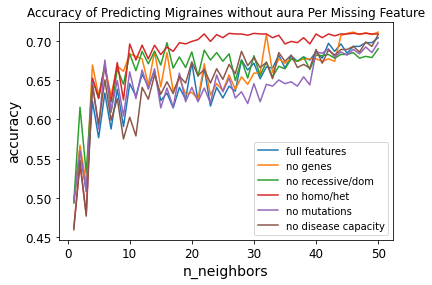

```python
ks = pd.Series(range(1, 51))
ks.index = range(1, 51)
full = ks.apply(knn_full)
no_gene = ks.apply(knn_no_gene)
no_rec_dom = ks.apply(knn_no_rec_dom)
no_homo_hetero = ks.apply(knn_no_homo_hetero)
no_mutate = ks.apply(knn_no_mutate)
no_disease = ks.apply(knn_no_disease)
plt.plot(full,label = 'full features')
plt.plot(no_gene,label = 'no genes')
plt.plot(no_rec_dom,label = 'no recessive/dom')
plt.plot(no_homo_hetero,label = 'no homo/het')
plt.plot(no_mutate,label = 'no mutations')
plt.plot(no_disease,label = 'no disease capacity')
plt.xlabel('n_neighbors')
plt.ylabel('accuracy')
plt.title('Accuracy of Predicting Migraines without aura Per Missing Feature')
plt.legend()
# Harder to interpret, seems that homo/hetero has much smaller effect on Migraines without aura
```

**For predicting migraines without aura, eliminating whether there was a mutation appeared to decrease accuracy the most. It also shows a positive relationship between accuracy and increasing neighbors**

Overall, it appears our models were not incredibly informative. However, they showed there could be a statistical relationship between certain comorbidities and specific genes. Additional data sources and further research would need to be conducted to validify any of these claims